# Scala with Cats

### 6.4.4 Exercise: Form Validation

Let’s get used to `Validated` by implementing a simple HTML registration form. We receive request data from the client in a `Map[String, String]` and we want to parse it to create a `User` object:

```scala
case class User(name: String, age: Int)
```

Our goal is to implement code that parses the incoming data enforcing the following rules:

- the name and age must be specified;
- the name must not be blank;
- the age must be a valid non-negative integer.

If all the rules pass our parser we should return a `User`. If any rules fail we should return a `List` of the error messages.

To implement this example we’ll need to combine rules in sequence and in parallel. We’ll use `Either` to combine computations in sequence using fail-fast semantics, and `Validated` to combine them in parallel using accumulating semantics.

Let’s start with some sequential combination. We’ll define two methods to read the `"name"` and `"age"` fields:

- `readName` will take a `Map[String, String]` parameter, extract the `"name"` field, check the relevant validation rules, and return an `Either[List[String], String]`.
- `readAge` will take a `Map[String, String]` parameter, extract the `"age"` field, check the relevant validation rules, and return an `Either[List[String], Int]`.

We’ll build these methods up from smaller building blocks. Start by defining a method `getValue` that reads a `String` from the `Map` given a field name.

We’ll be using `Either` and `Validated` so we’ll start with some imports:

```scala
import cats.data.Validated

type FormData = Map[String, String]
type FailFast[A] = Either[List[String], A]
type FailSlow[A] = Validated[List[String], A]
```

The `getValue` rule extracts a `String` from the form data. We’ll be using it in sequence with rules for parsing `Ints` and checking values, so we’ll define it to return an `Either`:

```scala
def getValue(name: String)(data: FormData): FailFast[String] =
  data.get(name).
    toRight(List(s"$name field not specified"))
```

We can create and use an instance of `getValue` as follows:

```scala
val getName = getValue("name") _
// getName: FormData => FailFast[String] = <function1>

getName(Map("name" -> "Dade Murphy"))
// res27: FailFast[String] = Right("Dade Murphy")
```

In the event of a missing field, our instance returns an error message containing an appropriate field name:

```scala
getName(Map())
// res28: FailFast[String] = Left(List("name field not specified"))
```

Next define a method `parseInt` that consumes a `String` and parses it as an `Int`.

We’ll use `Either` again here. We use `Either.catchOnly` to consume the `NumberFormatException` from `toInt`, and we use `leftMap` to turn it into an error message:

```scala
import cats.syntax.either._ // for catchOnly

type NumFmtExn = NumberFormatException

def parseInt(name: String)(data: String): FailFast[Int] =
  Either.catchOnly[NumFmtExn](data.toInt).
    leftMap(_ => List(s"$name must be an integer"))
```

Note that our solution accepts an extra parameter to name the field we’re parsing. This is useful for creating better error messages, but it’s fine if you leave it out in your code.

If we provide valid input, `parseInt` converts it to an `Int`:

```scala
parseInt("age")("11")
// res29: FailFast[Int] = Right(11)
```

If we provide erroneous input, we get a useful error message:

```scala
parseInt("age")("foo")
// res30: FailFast[Int] = Left(List("age must be an integer"))
```

Next implement the validation checks: `nonBlank` to check `Strings`, and `nonNegative` to check `Ints`.

These definitions use the same patterns as above:

```scala
def nonBlank(name: String)(data: String): FailFast[String] =
  Right(data).
    ensure(List(s"$name cannot be blank"))(_.nonEmpty)

def nonNegative(name: String)(data: Int): FailFast[Int] =
  Right(data).
    ensure(List(s"$name must be non-negative"))(_ >= 0)
```

Here are some examples of use:

```scala
nonBlank("name")("Dade Murphy")
// res31: FailFast[String] = Right("Dade Murphy")
nonBlank("name")("")
// res32: FailFast[String] = Left(List("name cannot be blank"))
nonNegative("age")(11)
// res33: FailFast[Int] = Right(11)
nonNegative("age")(-1)
// res34: FailFast[Int] = Left(List("age must be non-negative"))
```

Now combine `getValue`, `parseInt`, `nonBlank` and `nonNegative` to create `readName` and `readAge`:

We use `flatMap` to combine the rules sequentially:

```scala
def readName(data: FormData): FailFast[String] =
  getValue("name")(data).
    flatMap(nonBlank("name"))

def readAge(data: FormData): FailFast[Int] =
  getValue("age")(data).
    flatMap(nonBlank("age")).
    flatMap(parseInt("age")).
    flatMap(nonNegative("age"))
```

The rules pick up all the error cases we’ve seen so far:

```scala
readName(Map("name" -> "Dade Murphy"))
// res35: FailFast[String] = Right("Dade Murphy")
readName(Map("name" -> ""))
// res36: FailFast[String] = Left(List("name cannot be blank"))
readName(Map())
// res37: FailFast[String] = Left(List("name field not specified"))
readAge(Map("age" -> "11"))
// res38: FailFast[Int] = Right(11)
readAge(Map("age" -> "-1"))
// res39: FailFast[Int] = Left(List("age must be non-negative"))
readAge(Map())
// res40: FailFast[Int] = Left(List("age field not specified"))
```

Finally, use a `Semigroupal` to combine the results of `readName` and `readAge` to produce a `User`. Make sure you switch from `Either` to `Validated` to accumulate errors.

We can do this by switching from `Either` to `Validated` and using apply syntax:

```scala
import cats.instances.list._ // for Semigroupal
import cats.syntax.apply._   // for mapN

def readUser(data: FormData): FailSlow[User] =
  (
    readName(data).toValidated,
    readAge(data).toValidated
  ).mapN(User.apply)

readUser(Map("name" -> "Dave", "age" -> "37"))
// res41: FailSlow[User] = Valid(User("Dave", 37))
readUser(Map("age" -> "-1"))
// res42: FailSlow[User] = Invalid(
//   List("name field not specified", "age must be non-negative")
// )
```

The need to switch back and forth between `Either` and `Validated` is annoying. The choice of whether to use `Either` or `Validated` as a default is determined by context. In application code, we typically find areas that favour accumulating semantics and areas that favour fail-fast semantics. We pick the data type that best suits our need and switch to the other as necessary in specific situations.

## 6.5 Apply and Applicative

Semigroupals aren’t mentioned frequently in the wider functional programming literature. They provide a subset of the functionality of a related type class called an *applicative functor* (“applicative” for short).

`Semigroupal` and `Applicative` effectively provide alternative encodings of the same notion of joining contexts. Both encodings are introduced in the [same 2008 paper](http://www.staff.city.ac.uk/~ross/papers/Applicative.html) by Conor McBride and Ross Paterson[^10].

Cats models applicatives using two type classes. The first, [`cats.Apply`](http://typelevel.org/cats/api/cats/Apply.html), extends `Semigroupal` and `Functor` and adds an `ap` method that applies a parameter to a function within a context. The second, [`cats.Applicative`](http://typelevel.org/cats/api/cats/Applicative.html), extends `Apply`, adds the `pure` method introduced in Chapter 4. Here’s a simplified definition in code:

```scala
trait Apply[F[_]] extends Semigroupal[F] with Functor[F] {
  def ap[A, B](ff: F[A => B])(fa: F[A]): F[B]

  def product[A, B](fa: F[A], fb: F[B]): F[(A, B)] =
    ap(map(fa)(a => (b: B) => (a, b)))(fb)
}

trait Applicative[F[_]] extends Apply[F] {
  def pure[A](a: A): F[A]
}
```

Breaking this down, the `ap` method applies a parameter `fa` to a function `ff` within a context `F[_]`. The `product` method from `Semigroupal` is defined in terms of `ap` and `map`.

Don’t worry too much about the implementation of `product`—it’s difficult to read and the details aren’t particuarly important. The main point is that there is a tight relationship between `product`, `ap`, and `map` that allows any one of them to be defined in terms of the other two.

`Applicative` also introduces the `pure` method. This is the same `pure` we saw in `Monad`. It constructs a new applicative instance from an unwrapped value. In this sense, `Applicative` is related to `Apply` as `Monoid` is related to `Semigroup`.

### 6.5.1 The Hierarchy of Sequencing Type Classes

With the introduction of `Apply` and `Applicative`, we can zoom out and see a whole family of type classes that concern themselves with sequencing computations in different ways. Figure 10 shows the relationship between the type classes covered in this book[^11].

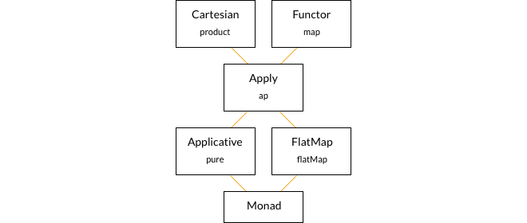

Figure 10: Monad type class hierarchy

Each type class in the hierarchy represents a particular set of sequencing semantics, introduces a set of characteristic methods, and defines the functionality of its supertypes in terms of them:

- every monad is an applicative;
- every applicative a semigroupal;
- and so on.

Because of the lawful nature of the relationships between the type classes, the inheritance relationships are constant across all instances of a type class. `Apply` defines `product` in terms of `ap` and `map`; `Monad` defines `product`, `ap`, and `map`, in terms of `pure` and `flatMap`.

To illustrate this let’s consider two hypothetical data types:

- `Foo` is a monad. It has an instance of the `Monad` type class that implements `pure` and `flatMap` and inherits standard definitions of `product`, `map`, and `ap`;
- `Bar` is an applicative functor. It has an instance of `Applicative` that implements `pure` and `ap` and inherits standard definitions of `product` and `map`.

What can we say about these two data types without knowing more about their implementation?

We know strictly more about `Foo` than `Bar`: `Monad` is a subtype of `Applicative`, so we can guarantee properties of `Foo` (namely `flatMap`) that we cannot guarantee with `Bar`. Conversely, we know that `Bar` may have a wider range of behaviours than `Foo`. It has fewer laws to obey (no `flatMap`), so it can implement behaviours that `Foo` cannot.

This demonstrates the classic trade-off of power (in the mathematical sense) versus constraint. The more constraints we place on a data type, the more guarantees we have about its behaviour, but the fewer behaviours we can model.

Monads happen to be a sweet spot in this trade-off. They are flexible enough to model a wide range of behaviours and restrictive enough to give strong guarantees about those behaviours. However, there are situations where monads aren’t the right tool for the job. Sometimes we want Thai food, and burritos just won’t satisfy.

Whereas monads impose a strict *sequencing* on the computations they model, applicatives and semigroupals impose no such restriction. This puts them in a different sweet spot in the hierarchy. We can use them to represent classes of parallel / independent computations that monads cannot.

We choose our semantics by choosing our data structures. If we choose a monad, we get strict sequencing. If we choose an applicative, we lose the ability to `flatMap`. This is the trade-off enforced by the consistency laws. So choose your types carefully!

## 6.6 Summary

While monads and functors are the most widely used sequencing data types we’ve covered in this book, semigroupals and applicatives are the most general. These type classes provide a generic mechanism to combine values and apply functions within a context, from which we can fashion monads and a variety of other combinators.

`Semigroupal` and `Applicative` are most commonly used as a means of combining independent values such as the results of validation rules. Cats provides the `Validated` type for this specific purpose, along with apply syntax as a convenient way to express the combination of rules.

We have almost covered all of the functional programming concepts on our agenda for this book. The next chapter covers `Traverse` and `Foldable`, two powerful type classes for converting between data types. After that we’ll look at several case studies that bring together all of the concepts from Part I.

# 7 Foldable and Traverse

In this chapter we’ll look at two type classes that capture iteration over collections:

- `Foldable` abstracts the familiar `foldLeft` and `foldRight` operations;
- `Traverse` is a higher-level abstraction that uses `Applicatives` to iterate with less pain than folding.

We’ll start by looking at `Foldable`, and then examine cases where folding becomes complex and `Traverse` becomes convenient.

## 7.1 Foldable

The `Foldable` type class captures the `foldLeft` and `foldRight` methods we’re used to in sequences like `Lists`, `Vectors`, and `Streams`. Using `Foldable`, we can write generic folds that work with a variety of sequence types. We can also invent new sequences and plug them into our code. `Foldable` gives us great use cases for `Monoids` and the `Eval` monad.

### 7.1.1 Folds and Folding

Let’s start with a quick recap of the general concept of folding. We supply an *accumulator* value and a *binary function* to combine it with each item in the sequence:

```scala
def show[A](list: List[A]): String =
  list.foldLeft("nil")((accum, item) => s"$item then $accum")

show(Nil)
// res0: String = "nil"

show(List(1, 2, 3))
// res1: String = "3 then 2 then 1 then nil"
```

The `foldLeft` method works recursively down the sequence. Our binary function is called repeatedly for each item, the result of each call becoming the accumulator for the next. When we reach the end of the sequence, the final accumulator becomes our final result.

Depending on the operation we’re performing, the order in which we fold may be important. Because of this there are two standard variants of fold:

- `foldLeft` traverses from “left” to “right” (start to finish);
- `foldRight` traverses from “right” to “left” (finish to start).

Figure 11 illustrates each direction.

[figure not shown]

Figure 11: Illustration of foldLeft and foldRight

`foldLeft` and `foldRight` are equivalent if our binary operation is associative. For example, we can sum a `List[Int]` by folding in either direction, using `0` as our accumulator and addition as our operation:

```scala
List(1, 2, 3).foldLeft(0)(_ + _)
// res2: Int = 6
List(1, 2, 3).foldRight(0)(_ + _)
// res3: Int = 6
```

If we provide a non-associative operator the order of evaluation makes a difference. For example, if we fold using subtraction, we get different results in each direction:

```scala
List(1, 2, 3).foldLeft(0)(_ - _)
// res4: Int = -6
List(1, 2, 3).foldRight(0)(_ - _)
// res5: Int = 2
```

### 7.1.2 Exercise: Reflecting on Folds

Try using `foldLeft` and `foldRight` with an empty list as the accumulator and `::` as the binary operator. What results do you get in each case?

Folding from left to right reverses the list:

```scala
List(1, 2, 3).foldLeft(List.empty[Int])((a, i) => i :: a)
// res6: List[Int] = List(3, 2, 1)
```

Folding right to left copies the list, leaving the order intact:

```scala
List(1, 2, 3).foldRight(List.empty[Int])((i, a) => i :: a)
// res7: List[Int] = List(1, 2, 3)
```

Note that we have to carefully specify the type of the accumulator to avoid a type error. We use `List.empty[Int]` to avoid inferring the accumulator type as `Nil.type` or `List[Nothing]`:

```scala
List(1, 2, 3).foldRight(Nil)(_ :: _)
// error: type mismatch;
//  found   : List[Int]
//  required: scala.collection.immutable.Nil.type
// List(1, 2, 3).foldRight(Nil)(_ :: _)
//                                ^^^^
```

### 7.1.3 Exercise: Scaf-fold-ing Other Methods

`foldLeft` and `foldRight` are very general methods. We can use them to implement many of the other high-level sequence operations we know. Prove this to yourself by implementing substitutes for `List's` `map`, `flatMap`, `filter`, and `sum` methods in terms of `foldRight`.

Here are the solutions:

```scala
def map[A, B](list: List[A])(func: A => B): List[B] =
  list.foldRight(List.empty[B]) { (item, accum) =>
    func(item) :: accum
  }

map(List(1, 2, 3))(_ * 2)
// res9: List[Int] = List(2, 4, 6)

def flatMap[A, B](list: List[A])(func: A => List[B]): List[B] =
  list.foldRight(List.empty[B]) { (item, accum) =>
    func(item) ::: accum
  }

flatMap(List(1, 2, 3))(a => List(a, a * 10, a * 100))
// res10: List[Int] = List(1, 10, 100, 2, 20, 200, 3, 30, 300)

def filter[A](list: List[A])(func: A => Boolean): List[A] =
  list.foldRight(List.empty[A]) { (item, accum) =>
    if(func(item)) item :: accum else accum
  }

filter(List(1, 2, 3))(_ % 2 == 1)
// res11: List[Int] = List(1, 3)
```

We’ve provided two definitions of `sum`, one using `scala.math.Numeric` (which recreates the built-in functionality accurately)…

```scala
import scala.math.Numeric

def sumWithNumeric[A](list: List[A])
      (implicit numeric: Numeric[A]): A =
  list.foldRight(numeric.zero)(numeric.plus)

sumWithNumeric(List(1, 2, 3))
// res12: Int = 6
```

and one using `cats.Monoid` (which is more appropriate to the content of this book):

```scala
import cats.Monoid

def sumWithMonoid[A](list: List[A])
      (implicit monoid: Monoid[A]): A =
  list.foldRight(monoid.empty)(monoid.combine)

import cats.instances.int._ // for Monoid

sumWithMonoid(List(1, 2, 3))
// res13: Int = 6
```

### 7.1.4 Foldable in Cats

Cats’ `Foldable` abstracts `foldLeft` and `foldRight` into a type class. Instances of `Foldable` define these two methods and inherit a host of derived methods. Cats provides out-of-the-box instances of `Foldable` for a handful of Scala data types: `List`, `Vector`, `LazyList`, and `Option`.

We can summon instances as usual using `Foldable.apply` and call their implementations of `foldLeft` directly. Here is an example using `List`:

```scala
import cats.Foldable
import cats.instances.list._ // for Foldable

val ints = List(1, 2, 3)

Foldable[List].foldLeft(ints, 0)(_ + _)
// res0: Int = 6
```

Other sequences like `Vector` and `LazyList` work in the same way. Here is an example using `Option`, which is treated like a sequence of zero or one elements:

```scala
import cats.instances.option._ // for Foldable

val maybeInt = Option(123)

Foldable[Option].foldLeft(maybeInt, 10)(_ * _)
// res1: Int = 1230
```

#### 7.1.4.1 Folding Right

`Foldable` defines `foldRight` differently to `foldLeft`, in terms of the `Eval` monad:

```scala
def foldRight[A, B](fa: F[A], lb: Eval[B])
                     (f: (A, Eval[B]) => Eval[B]): Eval[B]
```

Using `Eval` means folding is always *stack safe*, even when the collection’s default definition of `foldRight` is not. For example, the default implementation of `foldRight` for `LazyList` is not stack safe. The longer the lazy list, the larger the stack requirements for the fold. A sufficiently large lazy list will trigger a `StackOverflowError`:

```scala
import cats.Eval
import cats.Foldable

def bigData = (1 to 100000).to(LazyList)

bigData.foldRight(0L)(_ + _)
// java.lang.StackOverflowError ...
```

Using `Foldable` forces us to use stack safe operations, which fixes the overflow exception:

```scala
import cats.instances.lazyList._ // for Foldable

val eval: Eval[Long] =
  Foldable[LazyList].
    foldRight(bigData, Eval.now(0L)) { (num, eval) =>
      eval.map(_ + num)
    }

eval.value
// res3: Long = 5000050000L
```

*Stack Safety in the Standard Library*

Stack safety isn’t typically an issue when using the standard library. The most commonly used collection types, such as `List` and `Vector`, provide stack safe implementations of `foldRight`:

```scala
(1 to 100000).toList.foldRight(0L)(_ + _)
// res4: Long = 5000050000L
(1 to 100000).toVector.foldRight(0L)(_ + _)
// res5: Long = 5000050000L
```

We’ve called out `Stream` because it is an exception to this rule. Whatever data type we’re using, though, it’s useful to know that `Eval` has our back.

#### 7.1.4.2 Folding with Monoids

`Foldable` provides us with a host of useful methods defined on top of `foldLeft`. Many of these are facsimiles of familiar methods from the standard library: `find`, `exists`, `forall`, `toList`, `isEmpty`, `nonEmpty`, and so on:

```scala
Foldable[Option].nonEmpty(Option(42))
// res6: Boolean = true

Foldable[List].find(List(1, 2, 3))(_ % 2 == 0)
// res7: Option[Int] = Some(2)
```

In addition to these familiar methods, Cats provides two methods that make use of `Monoids`:

- `combineAll` (and its alias `fold`) combines all elements in the sequence using their `Monoid`;
- `foldMap` maps a user-supplied function over the sequence and combines the results using a `Monoid`.

For example, we can use `combineAll` to sum over a `List[Int]`:

```scala
import cats.instances.int._ // for Monoid

Foldable[List].combineAll(List(1, 2, 3))
// res8: Int = 6
```

Alternatively, we can use `foldMap` to convert each `Int` to a `String` and concatenate them:

```scala
import cats.instances.string._ // for Monoid

Foldable[List].foldMap(List(1, 2, 3))(_.toString)
// res9: String = "123"
```

Finally, we can compose `Foldables` to support deep traversal of nested sequences:

```scala
import cats.instances.vector._ // for Monoid

val ints = List(Vector(1, 2, 3), Vector(4, 5, 6))

(Foldable[List] compose Foldable[Vector]).combineAll(ints)
// res11: Int = 21
```

#### 7.1.4.3 Syntax for Foldable

Every method in `Foldable` is available in syntax form via [`cats.syntax.foldable`](http://typelevel.org/cats/api/cats/syntax/package$$foldable$). In each case, the first argument to the method on `Foldable` becomes the receiver of the method call:

```scala
import cats.syntax.foldable._ // for combineAll and foldMap

List(1, 2, 3).combineAll
// res12: Int = 6

List(1, 2, 3).foldMap(_.toString)
// res13: String = "123"
```

*Explicits over Implicits*

Remember that Scala will only use an instance of `Foldable` if the method isn’t explicitly available on the receiver. For example, the following code will use the version of `foldLeft` defined on `List`:

```scala
List(1, 2, 3).foldLeft(0)(_ + _)
// res14: Int = 6
```

whereas the following generic code will use `Foldable`:

```scala
def sum[F[_]: Foldable](values: F[Int]): Int =
  values.foldLeft(0)(_ + _)
```

We typically don’t need to worry about this distinction. It’s a feature! We call the method we want and the compiler uses a `Foldable` when needed to ensure our code works as expected. If we need a stack-safe implementation of `foldRight`, using `Eval` as the accumulator is enough to force the compiler to select the method from Cats.

## 7.2 Traverse

`foldLeft` and `foldRight` are flexible iteration methods but they require us to do a lot of work to define accumulators and combinator functions. The `Traverse` type class is a higher level tool that leverages `Applicatives` to provide a more convenient, more lawful, pattern for iteration.

### 7.2.1 Traversing with Futures

We can demonstrate `Traverse` using the `Future.traverse` and `Future.sequence` methods in the Scala standard library. These methods provide `Future`-specific implementations of the traverse pattern. As an example, suppose we have a list of server hostnames and a method to poll a host for its uptime:

```scala
import scala.concurrent._
import scala.concurrent.duration._
import scala.concurrent.ExecutionContext.Implicits.global

val hostnames = List(
  "alpha.example.com",
  "beta.example.com",
  "gamma.demo.com"
)

def getUptime(hostname: String): Future[Int] =
  Future(hostname.length * 60) // just for demonstration
```

Now, suppose we want to poll all of the hosts and collect all of their uptimes. We can’t simply `map` over `hostnames` because the result—a `List[Future[Int]]`—would contain more than one `Future`. We need to reduce the results to a single `Future` to get something we can block on. Let’s start by doing this manually using a fold:

```scala
val allUptimes: Future[List[Int]] =
  hostnames.foldLeft(Future(List.empty[Int])) {
    (accum, host) =>
      val uptime = getUptime(host)
      for {
        accum  <- accum
        uptime <- uptime
      } yield accum :+ uptime
  }

Await.result(allUptimes, 1.second)
// res0: List[Int] = List(1020, 960, 840)
```

Intuitively, we iterate over `hostnames`, call `func` for each item, and combine the results into a list. This sounds simple, but the code is fairly unwieldy because of the need to create and combine `Futures` at every iteration. We can improve on things greatly using `Future.traverse`, which is tailor-made for this pattern:

```scala
val allUptimes: Future[List[Int]] =
  Future.traverse(hostnames)(getUptime)

Await.result(allUptimes, 1.second)
// res2: List[Int] = List(1020, 960, 840)
```

This is much clearer and more concise—let’s see how it works. If we ignore distractions like `CanBuildFrom` and `ExecutionContext`, the implementation of `Future.traverse` in the standard library looks like this:

```scala
def traverse[A, B](values: List[A])
    (func: A => Future[B]): Future[List[B]] =
  values.foldLeft(Future(List.empty[B])) { (accum, host) =>
    val item = func(host)
    for {
      accum <- accum
      item  <- item
    } yield accum :+ item
  }
```

This is essentially the same as our example code above. `Future.traverse` is abstracting away the pain of folding and defining accumulators and combination functions. It gives us a clean high-level interface to do what we want:

- start with a `List[A]`;
- provide a function `A => Future[B]`;
- end up with a `Future[List[B]]`.

The standard library also provides another method, `Future.sequence`, that assumes we’re starting with a `List[Future[B]]` and don’t need to provide an identity function:

```scala
object Future {
  def sequence[B](futures: List[Future[B]]): Future[List[B]] =
    traverse(futures)(identity)

  // etc...
}
```

In this case the intuitive understanding is even simpler:

- start with a `List[Future[A]]`;
- end up with a `Future[List[A]]`.

`Future.traverse` and `Future.sequence` solve a very specific problem: they allow us to iterate over a sequence of `Futures` and accumulate a result. The simplified examples above only work with `Lists`, but the real `Future.traverse` and `Future.sequence` work with any standard Scala collection.

Cats’ `Traverse` type class generalises these patterns to work with any type of `Applicative`: `Future`, `Option`, `Validated`, and so on. We’ll approach `Traverse` in the next sections in two steps: first we’ll generalise over the `Applicative`, then we’ll generalise over the sequence type. We’ll end up with an extremely valuable tool that trivialises many operations involving sequences and other data types.

### 7.2.2 Traversing with Applicatives

If we squint, we’ll see that we can rewrite `traverse` in terms of an `Applicative`. Our accumulator from the example above:

```scala
Future(List.empty[Int])
```

is equivalent to `Applicative.pure`:

```scala
import cats.Applicative
import cats.instances.future._   // for Applicative
import cats.syntax.applicative._ // for pure

List.empty[Int].pure[Future]
```

Our combinator, which used to be this:

```scala
def oldCombine(
  accum : Future[List[Int]],
  host  : String
): Future[List[Int]] = {
  val uptime = getUptime(host)
  for {
    accum  <- accum
    uptime <- uptime
  } yield accum :+ uptime
}
```

is now equivalent to `Semigroupal.combine`:

```scala
import cats.syntax.apply._ // for mapN

// Combining accumulator and hostname using an Applicative:
def newCombine(accum: Future[List[Int]],
      host: String): Future[List[Int]] =
  (accum, getUptime(host)).mapN(_ :+ _)
```

By substituting these snippets back into the definition of `traverse` we can generalise it to to work with any `Applicative`:

```scala
def listTraverse[F[_]: Applicative, A, B]
      (list: List[A])(func: A => F[B]): F[List[B]] =
  list.foldLeft(List.empty[B].pure[F]) { (accum, item) =>
    (accum, func(item)).mapN(_ :+ _)
  }

def listSequence[F[_]: Applicative, B]
      (list: List[F[B]]): F[List[B]] =
  listTraverse(list)(identity)
```

We can use `listTraverse` to re-implement our uptime example:

```scala
val totalUptime = listTraverse(hostnames)(getUptime)

Await.result(totalUptime, 1.second)
// res5: List[Int] = List(1020, 960, 840)
```

or we can use it with other `Applicative` data types as shown in the following exercises.

#### 7.2.2.1 Exercise: Traversing with Vectors

What is the result of the following?

```scala
import cats.instances.vector._ // for Applicative

listSequence(List(Vector(1, 2), Vector(3, 4)))
```

The argument is of type `List[Vector[Int]]`, so we’re using the `Applicative` for `Vector` and the return type is going to be `Vector[List[Int]]`.

`Vector` is a monad, so its semigroupal `combine` function is based on `flatMap`. We’ll end up with a `Vector` of `Lists` of all the possible combinations of `List(1, 2)` and `List(3, 4)`:

```scala
listSequence(List(Vector(1, 2), Vector(3, 4)))
// res7: Vector[List[Int]] = Vector(
//   List(1, 3),
//   List(1, 4),
//   List(2, 3),
//   List(2, 4)
// )
```

What about a list of three parameters?

```scala
listSequence(List(Vector(1, 2), Vector(3, 4), Vector(5, 6)))
```

With three items in the input list, we end up with combinations of three `Ints`: one from the first item, one from the second, and one from the third:

```scala
listSequence(List(Vector(1, 2), Vector(3, 4), Vector(5, 6)))
// res9: Vector[List[Int]] = Vector(
//   List(1, 3, 5),
//   List(1, 3, 6),
//   List(1, 4, 5),
//   List(1, 4, 6),
//   List(2, 3, 5),
//   List(2, 3, 6),
//   List(2, 4, 5),
//   List(2, 4, 6)
// )
```

#### 7.2.2.2 Exercise: Traversing with Options

Here’s an example that uses `Options`:

```scala
import cats.instances.option._ // for Applicative

def process(inputs: List[Int]) =
  listTraverse(inputs)(n => if(n % 2 == 0) Some(n) else None)
```

What is the return type of this method? What does it produce for the following inputs?

```scala
process(List(2, 4, 6))
process(List(1, 2, 3))
```

The arguments to `listTraverse` are of types `List[Int]` and `Int => Option[Int]`, so the return type is `Option[List[Int]]`. Again, `Option` is a monad, so the semigroupal `combine` function follows from `flatMap`. The semantics are therefore fail-fast error handling: if all inputs are even, we get a list of outputs. Otherwise we get `None`:

```scala
process(List(2, 4, 6))
// res12: Option[List[Int]] = Some(List(2, 4, 6))
process(List(1, 2, 3))
// res13: Option[List[Int]] = None
```

#### 7.2.2.3 Exercise: Traversing with Validated

Finally, here is an example that uses `Validated`:

```scala
import cats.data.Validated
import cats.instances.list._ // for Monoid

type ErrorsOr[A] = Validated[List[String], A]

def process(inputs: List[Int]): ErrorsOr[List[Int]] =
  listTraverse(inputs) { n =>
    if(n % 2 == 0) {
      Validated.valid(n)
    } else {
      Validated.invalid(List(s"$n is not even"))
    }
  }
```

What does this method produce for the following inputs?

```scala
process(List(2, 4, 6))
process(List(1, 2, 3))
```

The return type here is `ErrorsOr[List[Int]]`, which expands to `Validated[List[String], List[Int]]`. The semantics for semigroupal `combine` on validated are accumulating error handling, so the result is either a list of even `Ints`, or a list of errors detailing which `Ints` failed the test:

```scala
process(List(2, 4, 6))
// res17: ErrorsOr[List[Int]] = Valid(List(2, 4, 6))
process(List(1, 2, 3))
// res18: ErrorsOr[List[Int]] = Invalid(List("1 is not even", "3 is not even"))
```

### 7.2.3 Traverse in Cats

Our `listTraverse` and `listSequence` methods work with any type of `Applicative`, but they only work with one type of sequence: `List`. We can generalise over different sequence types using a type class, which brings us to Cats’ `Traverse`. Here’s the abbreviated definition:

```scala
package cats

trait Traverse[F[_]] {
  def traverse[G[_]: Applicative, A, B]
      (inputs: F[A])(func: A => G[B]): G[F[B]]

  def sequence[G[_]: Applicative, B]
      (inputs: F[G[B]]): G[F[B]] =
    traverse(inputs)(identity)
}
```

Cats provides instances of `Traverse` for `List`, `Vector`, `Stream`, `Option`, `Either`, and a variety of other types. We can summon instances as usual using `Traverse.apply` and use the `traverse` and `sequence` methods as described in the previous section:

```scala
import cats.Traverse
import cats.instances.future._ // for Applicative
import cats.instances.list._   // for Traverse

val totalUptime: Future[List[Int]] =
  Traverse[List].traverse(hostnames)(getUptime)

Await.result(totalUptime, 1.second)
// res0: List[Int] = List(1020, 960, 840)

val numbers = List(Future(1), Future(2), Future(3))

val numbers2: Future[List[Int]] =
  Traverse[List].sequence(numbers)

Await.result(numbers2, 1.second)
// res1: List[Int] = List(1, 2, 3)
```

There are also syntax versions of the methods, imported via [`cats.syntax.traverse`](http://typelevel.org/cats/api/cats/syntax/package$$traverse$):

```scala
import cats.syntax.traverse._ // for sequence and traverse

Await.result(hostnames.traverse(getUptime), 1.second)
// res2: List[Int] = List(1020, 960, 840)
Await.result(numbers.sequence, 1.second)
// res3: List[Int] = List(1, 2, 3)
```

As you can see, this is much more compact and readable than the `foldLeft` code we started with earlier this chapter!

## 7.3 Summary

In this chapter we were introduced to `Foldable` and `Traverse`, two type classes for iterating over sequences.

`Foldable` abstracts the `foldLeft` and `foldRight` methods we know from collections in the standard library. It adds stack-safe implementations of these methods to a handful of extra data types, and defines a host of situationally useful additions. That said, `Foldable` doesn’t introduce much that we didn’t already know.

The real power comes from `Traverse`, which abstracts and generalises the `traverse` and `sequence` methods we know from `Future`. Using these methods we can turn an `F[G[A]]` into a `G[F[A]]` for any `F` with an instance of `Traverse` and any `G` with an instance of `Applicative`. In terms of the reduction we get in lines of code, `Traverse` is one of the most powerful patterns in this book. We can reduce `folds` of many lines down to a single `foo.traverse`.

…and with that, we’ve finished all of the theory in this book. There’s plenty more to come, though, as we put everything we’ve learned into practice in a series of in-depth case studies in Part II!

# 8 Case Study: Testing Asynchronous Code

We’ll start with a straightforward case study: how to simplify unit tests for asynchronous code by making them synchronous.

Let’s return to the example from Chapter 7 where we’re measuring the uptime on a set of servers. We’ll flesh out the code into a more complete structure. There will be two components. The first is an `UptimeClient` that polls remote servers for their uptime:

```scala
import scala.concurrent.Future

trait UptimeClient {
  def getUptime(hostname: String): Future[Int]
}
```

We’ll also have an `UptimeService` that maintains a list of servers and allows the user to poll them for their total uptime:

```scala
import cats.instances.future._ // for Applicative
import cats.instances.list._   // for Traverse
import cats.syntax.traverse._  // for traverse
import scala.concurrent.ExecutionContext.Implicits.global

class UptimeService(client: UptimeClient) {
  def getTotalUptime(hostnames: List[String]): Future[Int] =
    hostnames.traverse(client.getUptime).map(_.sum)
}
```

We’ve modelled `UptimeClient` as a trait because we’re going to want to stub it out in unit tests. For example, we can write a test client that allows us to provide dummy data rather than calling out to actual servers:

```scala
class TestUptimeClient(hosts: Map[String, Int]) extends UptimeClient {
  def getUptime(hostname: String): Future[Int] =
    Future.successful(hosts.getOrElse(hostname, 0))
}
```

Now, suppose we’re writing unit tests for `UptimeService`. We want to test its ability to sum values, regardless of where it is getting them from. Here’s an example:

```scala
def testTotalUptime() = {
  val hosts    = Map("host1" -> 10, "host2" -> 6)
  val client   = new TestUptimeClient(hosts)
  val service  = new UptimeService(client)
  val actual   = service.getTotalUptime(hosts.keys.toList)
  val expected = hosts.values.sum
  assert(actual == expected)
}
// error: No warnings can be incurred under -Werror.
```

The code doesn’t compile because we’ve made a classic error[^12]. We forgot that our application code is asynchronous. Our `actual` result is of type `Future[Int]` and our `expected` result is of type `Int`. We can’t compare them directly!

There are a couple of ways to solve this problem. We could alter our test code to accommodate the asynchronousness. However, there is another alternative. Let’s make our service code synchronous so our test works without modification!

## 8.1 Abstracting over Type Constructors

We need to implement two versions of `UptimeClient`: an asynchronous one for use in production and a synchronous one for use in our unit tests:

```scala
trait RealUptimeClient extends UptimeClient {
  def getUptime(hostname: String): Future[Int]
}

trait TestUptimeClient extends UptimeClient {
  def getUptime(hostname: String): Int
}
```

The question is: what result type should we give to the abstract method in `UptimeClient`? We need to abstract over `Future[Int]` and `Int`:

```scala
trait UptimeClient {
  def getUptime(hostname: String): ???
}
```

At first this may seem difficult. We want to retain the `Int` part from each type but “throw away” the `Future` part in the test code. Fortunately, Cats provides a solution in terms of the *identity type*, `Id`, that we discussed way back in Section 4.3. `Id` allows us to “wrap” types in a type constructor without changing their meaning:

```scala
package cats

type Id[A] = A
```

`Id` allows us to abstract over the return types in `UptimeClient`. Implement this now:

- write a trait definition for `UptimeClient` that accepts a type constructor `F[_]` as a parameter;
- extend it with two traits, `RealUptimeClient` and `TestUptimeClient`, that bind `F` to `Future` and `Id` respectively;
- write out the method signature for `getUptime` in each case to verify that it compiles.

Here’s the implementation:

```scala
import cats.Id

trait UptimeClient[F[_]] {
  def getUptime(hostname: String): F[Int]
}

trait RealUptimeClient extends UptimeClient[Future] {
  def getUptime(hostname: String): Future[Int]
}

trait TestUptimeClient extends UptimeClient[Id] {
  def getUptime(hostname: String): Id[Int]
}
```

Note that, because `Id[A]` is just a simple alias for `A`, we don’t need to refer to the type in `TestUptimeClient` as `Id[Int]`—we can simply write `Int` instead:

```scala
trait TestUptimeClient extends UptimeClient[Id] {
  def getUptime(hostname: String): Int
}
```

Of course, technically speaking we don’t need to redeclare `getUptime` in `RealUptimeClient` or `TestUptimeClient`. However, writing everything out helps illustrate the technique.

You should now be able to flesh your definition of `TestUptimeClient` out into a full class based on a `Map[String, Int]` as before.

The final code is similar to our original implementation of `TestUptimeClient`, except we no longer need the call to `Future.successful`:

```scala
class TestUptimeClient(hosts: Map[String, Int])
  extends UptimeClient[Id] {
  def getUptime(hostname: String): Int =
    hosts.getOrElse(hostname, 0)
}
```

## 8.2 Abstracting over Monads

Let’s turn our attention to `UptimeService`. We need to rewrite it to abstract over the two types of `UptimeClient`. We’ll do this in two stages: first we’ll rewrite the class and method signatures, then the method bodies. Starting with the method signatures:

- comment out the body of `getTotalUptime` (replace it with `???` to make everything compile);
- add a type parameter `F[_]` to `UptimeService` and pass it on to `UptimeClient`.

The code should look like this:

```scala
class UptimeService[F[_]](client: UptimeClient[F]) {
  def getTotalUptime(hostnames: List[String]): F[Int] =
    ???
    // hostnames.traverse(client.getUptime).map(_.sum)
}
```

Now uncomment the body of `getTotalUptime`. You should get a compilation error similar to the following:

```scala
// <console>:28: error: could not find implicit value for
//               evidence parameter of type cats.Applicative[F]
//            hostnames.traverse(client.getUptime).map(_.sum)
//                              ^
```

The problem here is that `traverse` only works on sequences of values that have an `Applicative`. In our original code we were traversing a `List[Future[Int]]`. There is an applicative for `Future` so that was fine. In this version we are traversing a `List[F[Int]]`. We need to *prove* to the compiler that `F` has an `Applicative`. Do this by adding an implicit constructor parameter to `UptimeService`.

We can write this as an implicit parameter:

```scala
import cats.Applicative
import cats.syntax.functor._ // for map

class UptimeService[F[_]](client: UptimeClient[F])
    (implicit a: Applicative[F]) {

  def getTotalUptime(hostnames: List[String]): F[Int] =
    hostnames.traverse(client.getUptime).map(_.sum)
}
```

or more tersely as a context bound:

```scala
class UptimeService[F[_]: Applicative]
    (client: UptimeClient[F]) {

  def getTotalUptime(hostnames: List[String]): F[Int] =
    hostnames.traverse(client.getUptime).map(_.sum)
}
```

Note that we need to import `cats.syntax.functor` as well as `cats.Applicative`. This is because we’re switching from using `future.map` to the Cats’ generic extension method that requires an implicit `Functor` parameter.

Finally, let’s turn our attention to our unit tests. Our test code now works as intended without any modification. We create an instance of `TestUptimeClient` and wrap it in an `UptimeService`. This effectively binds `F` to `Id`, allowing the rest of the code to operate synchronously without worrying about monads or applicatives:

```scala
def testTotalUptime() = {
  val hosts    = Map("host1" -> 10, "host2" -> 6)
  val client   = new TestUptimeClient(hosts)
  val service  = new UptimeService(client)
  val actual   = service.getTotalUptime(hosts.keys.toList)
  val expected = hosts.values.sum
  assert(actual == expected)
}

testTotalUptime()
```

## 8.3 Summary

This case study provides an example of how Cats can help us abstract over different computational scenarios. We used the `Applicative` type class to abstract over asynchronous and synchronous code. Leaning on a functional abstraction allows us to specify the sequence of computations we want to perform without worrying about the details of the implementation.

Back in Figure 10, we showed a “stack” of computational type classes that are meant for exactly this kind of abstraction. Type classes like `Functor`, `Applicative`, `Monad`, and `Traverse` provide abstract implementations of patterns such as mapping, zipping, sequencing, and iteration. The mathematical laws on those types ensure that they work together with a consistent set of semantics.

We used `Applicative` in this case study because it was the least powerful type class that did what we needed. If we had required `flatMap`, we could have swapped out `Applicative` for `Monad`. If we had needed to abstract over different sequence types, we could have used `Traverse`. There are also type classes like `ApplicativeError` and `MonadError` that help model failures as well as successful computations.

Let’s move on now to a more complex case study where type classes will help us produce something more interesting: a map-reduce-style framework for parallel processing.

# 9 Case Study: Map-Reduce

In this case study we’re going to implement a simple-but-powerful parallel processing framework using `Monoids`, `Functors`, and a host of other goodies.

If you have used Hadoop or otherwise worked in “big data” you will have heard of [MapReduce](http://research.google.com/archive/map-reduce.html), which is a programming model for doing parallel data processing across clusters of machines (aka “nodes”). As the name suggests, the model is built around a *map* phase, which is the same `map` function we know from Scala and the `Functor` type class, and a *reduce* phase, which we usually call `fold`[^13] in Scala.

## 9.1 Parallelizing *map* and *fold*

Recall the general signature for `map` is to apply a function `A => B` to a `F[A]`, returning a `F[B]`:

[figure not shown]

Figure 12: Type chart: functor map

`map` transforms each individual element in a sequence independently. We can easily parallelize `map` because there are no dependencies between the transformations applied to different elements (the type signature of the function `A => B` shows us this, assuming we don’t use side-effects not reflected in the types).

What about `fold`? We can implement this step with an instance of `Foldable`. Not every functor also has an instance of foldable but we can implement a map-reduce system on top of any data type that has both of these type classes. Our reduction step becomes a `foldLeft` over the results of the distributed `map`.

[figure not shown]

Figure 13: Type chart: fold

By distributing the reduce step we lose control over the order of traversal. Our overall reduction may not be entirely left-to-right—we may reduce left-to-right across several subsequences and then combine the results. To ensure correctness we need a reduction operation that is *associative*:

```scala
reduce(a1, reduce(a2, a3)) == reduce(reduce(a1, a2), a3)
```

If we have associativity, we can arbitrarily distribute work between our nodes provided the subsequences at every node stay in the same order as the initial dataset.

Our fold operation requires us to seed the computation with an element of type `B`. Since fold may be split into an arbitrary number of parallel steps, the seed should not affect the result of the computation. This naturally requires the seed to be an *identity* element:

```scala
reduce(seed, a1) == reduce(a1, seed) == a1
```

In summary, our parallel fold will yield the correct results if:

- we require the reducer function to be associative;
- we seed the computation with the identity of this function.

What does this pattern sound like? That’s right, we’ve come full circle back to `Monoid`, the first type class we discussed in this book. We are not the first to recognise the importance of monoids. The [monoid design pattern for map-reduce jobs](http://arxiv.org/abs/1304.7544) is at the core of recent big data systems such as Twitter’s [Summingbird](https://github.com/twitter/summingbird).

In this project we’re going to implement a very simple single-machine map-reduce. We’ll start by implementing a method called `foldMap` to model the data-flow we need.

## 9.2 Implementing *foldMap*

We saw `foldMap` briefly back when we covered `Foldable`. It is one of the derived operations that sits on top of `foldLeft` and `foldRight`. However, rather than use `Foldable`, we will re-implement `foldMap` here ourselves as it will provide useful insight into the structure of map-reduce.

Start by writing out the signature of `foldMap`. It should accept the following parameters:

- a sequence of type `Vector[A]`;
- a function of type `A => B`, where there is a `Monoid` for `B`;

You will have to add implicit parameters or context bounds to complete the type signature.

```scala
import cats.Monoid

/** Single-threaded map-reduce function.
  * Maps `func` over `values` and reduces using a `Monoid[B]`.
  */
def foldMap[A, B: Monoid](values: Vector[A])(func: A => B): B =
  ???
```

Now implement the body of `foldMap`. Use the flow chart in Figure 14 as a guide to the steps required:

1. start with a sequence of items of type `A`;
2. map over the list to produce a sequence of items of type `B`;
3. use the `Monoid` to reduce the items to a single `B`.

[figure not shown]

Figure 14: *foldMap* algorithm

Here’s some sample output for reference:

```scala
import cats.instances.int._ // for Monoid

foldMap(Vector(1, 2, 3))(identity)
// res1: Int = 6

import cats.instances.string._ // for Monoid

// Mapping to a String uses the concatenation monoid:
foldMap(Vector(1, 2, 3))(_.toString + "! ")
// res2: String = "1! 2! 3! "

// Mapping over a String to produce a String:
foldMap("Hello world!".toVector)(_.toString.toUpperCase)
// res3: String = "HELLO WORLD!"
```

We have to modify the type signature to accept a `Monoid` for `B`. With that change we can use the `Monoid` `empty` and `|+|` syntax as described in Section 2.5.3:

```scala
import cats.Monoid
import cats.syntax.semigroup._ // for |+|

def foldMap[A, B : Monoid](as: Vector[A])(func: A => B): B =
  as.map(func).foldLeft(Monoid[B].empty)(_ |+| _)
```

We can make a slight alteration to this code to do everything in one step:

```scala
def foldMap[A, B : Monoid](as: Vector[A])(func: A => B): B =
  as.foldLeft(Monoid[B].empty)(_ |+| func(_))
```

## 9.3 Parallelising *foldMap*

Now we have a working single-threaded implementation of `foldMap`, let’s look at distributing work to run in parallel. We’ll use our single-threaded version of `foldMap` as a building block.

We’ll write a multi-CPU implementation that simulates the way we would distribute work in a map-reduce cluster as shown in Figure 15:

1. we start with an initial list of all the data we need to process;
2. we divide the data into batches, sending one batch to each CPU;
3. the CPUs run a batch-level map phase in parallel;
4. the CPUs run a batch-level reduce phase in parallel, producing a local result for each batch;
5. we reduce the results for each batch to a single final result.

[figure not shown]

Figure 15: *parallelFoldMap* algorithm

Scala provides some simple tools to distribute work amongst threads. We could use the [parallel collections library](http://docs.scala-lang.org/overviews/parallel-collections/overview.html) to implement a solution, but let’s challenge ourselves by diving a bit deeper and implementing the algorithm ourselves using `Futures`.

### 9.3.1 *Futures*, Thread Pools, and ExecutionContexts

We already know a fair amount about the monadic nature of `Futures`. Let’s take a moment for a quick recap, and to describe how Scala futures are scheduled behind the scenes.

`Futures` run on a thread pool, determined by an implicit `ExecutionContext` parameter. Whenever we create a `Future`, whether through a call to `Future.apply` or some other combinator, we must have an implicit `ExecutionContext` in scope:

```scala
import scala.concurrent.Future
import scala.concurrent.ExecutionContext.Implicits.global

val future1 = Future {
  (1 to 100).toList.foldLeft(0)(_ + _)
}
// future1: Future[Int] = Future(Success(5050))

val future2 = Future {
  (100 to 200).toList.foldLeft(0)(_ + _)
}
// future2: Future[Int] = Future(Success(15150))
```

In this example we’ve imported a `ExecutionContext.Implicits.global`. This default context allocates a thread pool with one thread per CPU in our machine. When we create a `Future` the `ExecutionContext` schedules it for execution. If there is a free thread in the pool, the `Future` starts executing immediately. Most modern machines have at least two CPUs, so in our example it is likely that `future1` and `future2` will execute in parellel.

Some combinators create new `Futures` that schedule work based on the results of other `Futures`. The `map` and `flatMap` methods, for example, schedule computations that run as soon as their input values are computed and a CPU is available:

```scala
val future3 = future1.map(_.toString)
// future3: Future[String] = Future(Success(5050))

val future4 = for {
  a <- future1
  b <- future2
} yield a + b
// future4: Future[Int] = Future(Success(20200))
```

As we saw in Section 7.2, we can convert a `List[Future[A]]` to a `Future[List[A]]` using `Future.sequence`:

```scala
Future.sequence(List(Future(1), Future(2), Future(3)))
// res6: Future[List[Int]] = Future(Success(List(1, 2, 3)))
```

or an instance of `Traverse`:

```scala
import cats.instances.future._ // for Applicative
import cats.instances.list._   // for Traverse
import cats.syntax.traverse._  // for sequence

List(Future(1), Future(2), Future(3)).sequence
// res7: Future[List[Int]] = Future(Success(List(1, 2, 3)))
```

An `ExecutionContext` is required in either case. Finally, we can use `Await.result` to block on a `Future` until a result is available:

```scala
import scala.concurrent._
import scala.concurrent.duration._

Await.result(Future(1), 1.second) // wait for the result
// res8: Int = 1
```

There are also `Monad` and `Monoid` implementations for `Future` available from `cats.instances.future`:

```scala
import cats.{Monad, Monoid}
import cats.instances.int._    // for Monoid
import cats.instances.future._ // for Monad and Monoid

Monad[Future].pure(42)

Monoid[Future[Int]].combine(Future(1), Future(2))
```

### 9.3.2 Dividing Work

Now we’ve refreshed our memory of `Futures`, let’s look at how we can divide work into batches. We can query the number of available CPUs on our machine using an API call from the Java standard library:

```scala
Runtime.getRuntime.availableProcessors
// res11: Int = 4
```

```scala
(1 to 10).toList.grouped(3).toList
// res12: List[List[Int]] = List(
//   List(1, 2, 3),
//   List(4, 5, 6),
//   List(7, 8, 9),
//   List(10)
// )
```

### 9.3.3 Implementing *parallelFoldMap*

Implement a parallel version of `foldMap` called `parallelFoldMap`. Here is the type signature:

```scala
def parallelFoldMap[A, B : Monoid]
      (values: Vector[A])
      (func: A => B): Future[B] = ???
```

Use the techniques described above to split the work into batches, one batch per CPU. Process each batch in a parallel thread. Refer back to Figure 15 if you need to review the overall algorithm.

For bonus points, process the batches for each CPU using your implementation of `foldMap` from above.

Here is an annotated solution that splits out each `map` and `fold` into a separate line of code:

```scala
def parallelFoldMap[A, B: Monoid]
      (values: Vector[A])
      (func: A => B): Future[B] = {
  // Calculate the number of items to pass to each CPU:
  val numCores  = Runtime.getRuntime.availableProcessors
  val groupSize = (1.0 * values.size / numCores).ceil.toInt

  // Create one group for each CPU:
  val groups: Iterator[Vector[A]] =
    values.grouped(groupSize)

  // Create a future to foldMap each group:
  val futures: Iterator[Future[B]] =
    groups map { group =>
      Future {
        group.foldLeft(Monoid[B].empty)(_ |+| func(_))
      }
    }

  // foldMap over the groups to calculate a final result:
  Future.sequence(futures) map { iterable =>
    iterable.foldLeft(Monoid[B].empty)(_ |+| _)
  }
}

val result: Future[Int] =
  parallelFoldMap((1 to 1000000).toVector)(identity)

Await.result(result, 1.second)
// res14: Int = 1784293664
```

We can re-use our definition of `foldMap` for a more concise solution. Note that the local maps and reduces in steps 3 and 4 of Figure 15 are actually equivalent to a single call to `foldMap`, shortening the entire algorithm as follows:

```scala
def parallelFoldMap[A, B: Monoid]
      (values: Vector[A])
      (func: A => B): Future[B] = {
  val numCores  = Runtime.getRuntime.availableProcessors
  val groupSize = (1.0 * values.size / numCores).ceil.toInt

  val groups: Iterator[Vector[A]] =
    values.grouped(groupSize)

  val futures: Iterator[Future[B]] =
    groups.map(group => Future(foldMap(group)(func)))

  Future.sequence(futures) map { iterable =>
    iterable.foldLeft(Monoid[B].empty)(_ |+| _)
  }
}

val result: Future[Int] =
  parallelFoldMap((1 to 1000000).toVector)(identity)

Await.result(result, 1.second)
// res16: Int = 1784293664
```

### 9.3.4 *parallelFoldMap* with more Cats

Although we implemented `foldMap` ourselves above, the method is also available as part of the `Foldable` type class we discussed in Section 7.1.

Reimplement `parallelFoldMap` using Cats’ `Foldable` and `Traverseable` type classes.

We’ll restate all of the necessary imports for completeness:

```scala
import cats.Monoid

import cats.instances.int._    // for Monoid
import cats.instances.future._ // for Applicative and Monad
import cats.instances.vector._ // for Foldable and Traverse

import cats.syntax.foldable._  // for combineAll and foldMap
import cats.syntax.traverse._  // for traverse

import scala.concurrent._
import scala.concurrent.duration._
import scala.concurrent.ExecutionContext.Implicits.global
```

Here’s the implementation of `parallelFoldMap` delegating as much of the method body to Cats as possible:

```scala
def parallelFoldMap[A, B: Monoid]
      (values: Vector[A])
      (func: A => B): Future[B] = {
  val numCores  = Runtime.getRuntime.availableProcessors
  val groupSize = (1.0 * values.size / numCores).ceil.toInt

  values
    .grouped(groupSize)
    .toVector
    .traverse(group => Future(group.toVector.foldMap(func)))
    .map(_.combineAll)
}

val future: Future[Int] =
  parallelFoldMap((1 to 1000).toVector)(_ * 1000)

Await.result(future, 1.second)
// res18: Int = 500500000
```

The call to `vector.grouped` returns an `Iterable[Iterator[Int]]`. We sprinkle calls to `toVector` through the code to convert the data back to a form that Cats can understand. The call to `traverse` creates a `Future[Vector[Int]]` containing one `Int` per batch. The call to `map` then combines the `match` using the `combineAll` method from `Foldable`.

## 9.4 Summary

In this case study we implemented a system that imitates map-reduce as performed on a cluster. Our algorithm followed three steps:

1. batch the data and send one batch to each “node”;
2. perform a local map-reduce on each batch;
3. combine the results using monoid addition.

Our toy system emulates the batching behaviour of real-world map-reduce systems such as Hadoop. However, in reality we are running all of our work on a single machine where communcation between nodes is negligible. We don’t actually need to batch data to gain efficient parallel processing of a list. We can simply map using a `Functor` and reduce using a `Monoid`.

Regardless of the batching strategy, mapping and reducing with `Monoids` is a powerful and general framework that isn’t limited to simple tasks like addition and string concatenation. Most of the tasks data scientists perform in their day-to-day analyses can be cast as monoids. There are monoids for all the following:

- approximate sets such as the Bloom filter;
- set cardinality estimators, such as the HyperLogLog algorithm;
- vectors and vector operations like stochastic gradient descent;
- quantile estimators such as the t-digest

to name but a few.

# 10 Case Study: Data Validation

In this case study we will build a library for validation. What do we mean by validation? Almost all programs must check their input meets certain criteria. Usernames must not be blank, email addresses must be valid, and so on. This type of validation often occurs in web forms, but it could be performed on configuration files, on web service responses, and any other case where we have to deal with data that we can’t guarantee is correct. Authentication, for example, is just a specialised form of validation.

We want to build a library that performs these checks. What design goals should we have? For inspiration, let’s look at some examples of the types of checks we want to perform:

- A user must be over 18 years old or must have parental consent.
- A `String` ID must be parsable as a `Int` and the `Int` must correspond to a valid record ID.
- A bid in an auction must apply to one or more items and have a positive value.
- A username must contain at least four characters and all characters must be alphanumeric.
- An email address must contain a single `@` sign. Split the string at the `@`. The string to the left must not be empty. The string to the right must be at least three characters long and contain a dot.

With these examples in mind we can state some goals:

- We should be able to associate meaningful messages with each validation failure, so the user knows why their data is not valid.
- We should be able to combine small checks into larger ones. Taking the username example above, we should be able to express this by combining a check of length and a check for alphanumeric values.
- We should be able to transform data while we are checking it. There is an example above requiring we parse data, changing its type from `String` to `Int`.
- Finally, we should be able to accumulate all the failures in one go, so the user can correct all the issues before resubmitting.

These goals assume we’re checking a single piece of data. We will also need to combine checks across multiple pieces of data. For a login form, for example, we’ll need to combine the check results for the username and the password. This will turn out to be quite a small component of the library, so the majority of our time will focus on checking a single data item.

## 10.1 Sketching the Library Structure

Let’s start at the bottom, checking individual pieces of data. Before we start coding let’s try to develop a feel for what we’ll be building. We can use a graphical notation to help us. We’ll go through our goals one by one.

**Providing error messages**

Our first goal requires us to associate useful error messages with a check failure. The output of a check could be either the value being checked, if it passed the check, or some kind of error message. We can abstractly represent this as a value in a context, where the context is the possibility of an error message as shown in Figure 16.

[figure not shown]

Figure 16: A validation result

A check itself is therefore a function that transforms a value into a value in a context as shown in Figure 17.

[figure not shown]

Figure 17: A validation check

**Combine checks**

How do we combine smaller checks into larger ones? Is this an applicative or semigroupal as shown in Figure 18?

[figure not shown]

Figure 18: Applicative combination of checks

Not really. With applicative combination, both checks are applied to the same value and result in a tuple with the value repeated. What we want feels more like a monoid as shown in Figure 19. We can define a sensible identity—a check that always passes—and two binary combination operators—*and* and *or*:

[figure not shown]

Figure 19: Monoid combination of checks

We’ll probably be using *and* and *or* about equally often with our validation library and it will be annoying to continuously switch between two monoids for combining rules. We consequently won’t actually use the monoid API: we’ll use two separate methods, `and` and `or`, instead.

**Accumulating errors as we check**

Monoids also feel like a good mechanism for accumulating error messages. If we store messages as a `List` or `NonEmptyList`, we can even use a pre-existing monoid from inside Cats.

**Transforming data as we check it**

In addition to checking data, we also have the goal of transforming it. This seems like it should be a `map` or a `flatMap` depending on whether the transform can fail or not, so it seems we also want checks to be a monad as shown in Figure 20.

[figure not shown]

Figure 20: Monadic combination of checks

We’ve now broken down our library into familiar abstractions and are in a good position to begin development.

## 10.2 The Check Datatype

Our design revolves around a `Check`, which we said was a function from a value to a value in a context. As soon as you see this description you should think of something like

```scala
type Check[A] = A => Either[String, A]
```

Here we’ve represented the error message as a `String`. This is probably not the best representation. We may want to accumulate messages in a `List`, for example, or even use a different representation that allows for internationalization or standard error codes.

We could attempt to build some kind of `ErrorMessage` type that holds all the information we can think of. However, we can’t predict the user’s requirements. Instead let’s let the user specify what they want. We can do this by adding a second type parameter to `Check`:

```scala
type Check[E, A] = A => Either[E, A]
```

We will probably want to add custom methods to `Check` so let’s declare it as a `trait` instead of a type alias:

```scala
trait Check[E, A] {
  def apply(value: A): Either[E, A]

  // other methods...
}
```

As we said in [Essential Scala](http://underscore.io/books/essential-scala), there are two functional programming patterns that we should consider when defining a trait:

- we can make it a typeclass, or;
- we can make it an algebraic data type (and hence seal it).

Type classes allow us to unify disparate data types with a common interface. This doesn’t seem like what we’re trying to do here. That leaves us with an algebraic data type. Let’s keep that thought in mind as we explore the design a bit further.

## 10.3 Basic Combinators

Let’s add some combinator methods to `Check`, starting with `and`. This method combines two checks into one, succeeding only if both checks succeed. Think about implementing this method now. You should hit some problems. Read on when you do!

```scala
trait Check[E, A] {
  def and(that: Check[E, A]): Check[E, A] =
    ???

  // other methods...
}
```

The problem is: what do you do when *both* checks fail? The correct thing to do is to return both errors, but we don’t currently have any way to combine `Es`. We need a *type class* that abstracts over the concept of “accumulating” errors as shown in Figure 21 What type class do we know that looks like this? What method or operator should we use to implement the `•` operation?

[figure not shown]

Figure 21: Combining error messages

We need a `Semigroup` for `E`. Then we can combine values of `E` using the `combine` method or its associated `|+|` syntax:

```scala
import cats.Semigroup
import cats.instances.list._   // for Semigroup
import cats.syntax.semigroup._ // for |+|

val semigroup = Semigroup[List[String]]

// Combination using methods on Semigroup
semigroup.combine(List("Badness"), List("More badness"))
// res3: List[String] = List("Badness", "More badness")

// Combination using Semigroup syntax
List("Oh noes") |+| List("Fail happened")
// res4: List[String] = List("Oh noes", "Fail happened")
```

Note we don’t need a full `Monoid` because we don’t need the identity element. We should always try to keep our constraints as small as possible!

There is another semantic issue that will come up quite quickly: should `and` short-circuit if the first check fails. What do you think the most useful behaviour is?

We want to report all the errors we can, so we should prefer *not* short-circuiting whenever possible.

In the case of the `and` method, the two checks we’re combining are independent of one another. We can always run both rules and combine any errors we see.

Use this knowledge to implement `and`. Make sure you end up with the behaviour you expect!

There are at least two implementation strategies.

In the first we represent checks as functions. The `Check` data type becomes a simple wrapper for a function that provides our library of combinator methods. For the sake of disambiguation, we’ll call this implementation `CheckF`:

```scala
import cats.Semigroup
import cats.syntax.either._    // for asLeft and asRight
import cats.syntax.semigroup._ // for |+|

final case class CheckF[E, A](func: A => Either[E, A]) {
  def apply(a: A): Either[E, A] =
    func(a)

  def and(that: CheckF[E, A])
        (implicit s: Semigroup[E]): CheckF[E, A] =
    CheckF { a =>
      (this(a), that(a)) match {
        case (Left(e1),  Left(e2))  => (e1 |+| e2).asLeft
        case (Left(e),   Right(_))  => e.asLeft
        case (Right(_),  Left(e))   => e.asLeft
        case (Right(_), Right(_)) => a.asRight
      }
    }
}
```

Let’s test the behaviour we get. First we’ll setup some checks:

```scala
import cats.instances.list._ // for Semigroup

val a: CheckF[List[String], Int] =
  CheckF { v =>
    if(v > 2) v.asRight
    else List("Must be > 2").asLeft
  }

val b: CheckF[List[String], Int] =
  CheckF { v =>
    if(v < -2) v.asRight
    else List("Must be < -2").asLeft
  }

val check: CheckF[List[String], Int] =
  a and b
```

Now run the check with some data:

```scala
check(5)
// res5: Either[List[String], Int] = Left(List("Must be < -2"))
check(0)
// res6: Either[List[String], Int] = Left(List("Must be > 2", "Must be < -2"))
```

Excellent! Everything works as expected! We’re running both checks and accumulating errors as required.

What happens if we try to create checks that fail with a type that we can’t accumulate? For example, there is no `Semigroup` instance for `Nothing`. What happens if we create instances of `CheckF[Nothing, A]`?

```scala
val a: CheckF[Nothing, Int] =
  CheckF(v => v.asRight)

val b: CheckF[Nothing, Int] =
  CheckF(v => v.asRight)
```

We can create checks just fine but when we come to combine them we get an error we might expect:

```scala
val check = a and b
// error: could not find implicit value for parameter s: cats.Semigroup[Nothing]
//   a and b
//   ^^^^^^^
```

Now let’s see another implementation strategy. In this approach we model checks as an algebraic data type, with an explicit data type for each combinator. We’ll call this implementation `Check`:

```scala
sealed trait Check[E, A] {
  import Check._

  def and(that: Check[E, A]): Check[E, A] =
    And(this, that)

  def apply(a: A)(implicit s: Semigroup[E]): Either[E, A] =
    this match {
      case Pure(func) =>
        func(a)

      case And(left, right) =>
        (left(a), right(a)) match {
          case (Left(e1),  Left(e2))  => (e1 |+| e2).asLeft
          case (Left(e),   Right(_))  => e.asLeft
          case (Right(_),  Left(e))   => e.asLeft
          case (Right(_), Right(_)) => a.asRight
        }
    }
}
object Check {
  final case class And[E, A](
    left: Check[E, A],
    right: Check[E, A]) extends Check[E, A]

  final case class Pure[E, A](
    func: A => Either[E, A]) extends Check[E, A]

  def pure[E, A](f: A => Either[E, A]): Check[E, A] =
    Pure(f)
}
```

Let’s see an example:

```scala
val a: Check[List[String], Int] =
  Check.pure { v =>
    if(v > 2) v.asRight
    else List("Must be > 2").asLeft
  }

val b: Check[List[String], Int] =
  Check.pure { v =>
    if(v < -2) v.asRight
    else List("Must be < -2").asLeft
  }

val check: Check[List[String], Int] =
  a and b
```

While the ADT implementation is more verbose than the function wrapper implementation, it has the advantage of cleanly separating the structure of the computation (the ADT instance we create) from the process that gives it meaning (the `apply` method). From here we have a number of options:

- inspect and refactor checks after they are created;
- move the `apply` “interpreter” out into its own module;
- implement alternative interpreters providing other functionality (for example visualizing checks).

Because of its flexibility, we will use the ADT implementation for the rest of this case study.

Strictly speaking, `Either[E, A]` is the wrong abstraction for the output of our check. Why is this the case? What other data type could we use instead? Switch your implementation over to this new data type.

The implementation of `apply` for `And` is using the pattern for applicative functors. `Either` has an `Applicative` instance, but it doesn’t have the semantics we want. It fails fast instead of accumulating errors.

If we want to accumulate errors `Validated` is a more appropriate abstraction. As a bonus, we get more code reuse because we can lean on the applicative instance of `Validated` in the implementation of `apply`.

Here’s the complete implementation:

```scala
import cats.Semigroup
import cats.data.Validated
import cats.syntax.apply._     // for mapN

sealed trait Check[E, A] {
  import Check._

  def and(that: Check[E, A]): Check[E, A] =
    And(this, that)

  def apply(a: A)(implicit s: Semigroup[E]): Validated[E, A] =
    this match {
      case Pure(func) =>
        func(a)

      case And(left, right) =>
        (left(a), right(a)).mapN((_, _) => a)
    }
}
object Check {
  final case class And[E, A](
    left: Check[E, A],
    right: Check[E, A]) extends Check[E, A]

  final case class Pure[E, A](
    func: A => Validated[E, A]) extends Check[E, A]
}
```

Our implementation is looking pretty good now. Implement an `or` combinator to complement `and`.

This reuses the same technique for `and`. We have to do a bit more work in the `apply` method. Note that it’s OK to short-circuit in this case because the choice of rules is implicit in the semantics of “or”.

```scala
import cats.Semigroup
import cats.data.Validated
import cats.syntax.semigroup._ // for |+|
import cats.syntax.apply._     // for mapN
import cats.data.Validated._   // for Valid and Invalid

sealed trait Check[E, A] {
  import Check._

  def and(that: Check[E, A]): Check[E, A] =
    And(this, that)

  def or(that: Check[E, A]): Check[E, A] =
    Or(this, that)

  def apply(a: A)(implicit s: Semigroup[E]): Validated[E, A] =
    this match {
      case Pure(func) =>
        func(a)

      case And(left, right) =>
        (left(a), right(a)).mapN((_, _) => a)

      case Or(left, right) =>
        left(a) match {
          case Valid(a)    => Valid(a)
          case Invalid(e1) =>
            right(a) match {
              case Valid(a)    => Valid(a)
              case Invalid(e2) => Invalid(e1 |+| e2)
            }
        }
    }
}
object Check {
  final case class And[E, A](
    left: Check[E, A],
    right: Check[E, A]) extends Check[E, A]

  final case class Or[E, A](
    left: Check[E, A],
    right: Check[E, A]) extends Check[E, A]

  final case class Pure[E, A](
    func: A => Validated[E, A]) extends Check[E, A]
}
```

With `and` and `or` we can implement many of checks we’ll want in practice. However, we still have a few more methods to add. We’ll turn to `map` and related methods next.

## 10.4 Transforming Data

One of our requirements is the ability to transform data. This allows us to support additional scenarios like parsing input. In this section we’ll extend our check library with this additional functionality.

The obvious starting point is `map`. When we try to implement this, we immediately run into a wall. Our current definition of `Check` requires the input and output types to be the same:

```scala
type Check[E, A] = A => Either[E, A]
```

When we map over a check, what type do we assign to the result? It can’t be `A` and it can’t be `B`. We are at an impasse:

```scala
def map(check: Check[E, A])(func: A => B): Check[E, ???]
```

To implement `map` we need to change the definition of `Check`. Specifically, we need to a new type variable to separate the input type from the output:

```scala
type Check[E, A, B] = A => Either[E, B]
```

Checks can now represent operations like parsing a `String` as an `Int`:

```scala
val parseInt: Check[List[String], String, Int] =
  // etc...
```

However, splitting our input and output types raises another issue. Up until now we have operated under the assumption that a `Check` always returns its input when successful. We used this in `and` and `or` to ignore the output of the left and right rules and simply return the original input on success:

```scala
(this(a), that(a)) match {
  case And(left, right) =>
    (left(a), right(a))
      .mapN((result1, result2) => Right(a))

  // etc...
}
```

In our new formulation we can’t return `Right(a)` because its type is `Either[E, A]` not `Either[E, B]`. We’re forced to make an arbitrary choice between returning `Right(result1)` and `Right(result2)`. The same is true of the `or` method. From this we can derive two things:

- we should strive to make the laws we adhere to explicit; and
- the code is telling us we have the wrong abstraction in `Check`.

### 10.4.1 Predicates

We can make progress by pulling apart the concept of a *predicate*, which can be combined using logical operations such as *and* and *or*, and the concept of a *check*, which can transform data.

What we have called `Check` so far we will call `Predicate`. For `Predicate` we can state the following *identity law* encoding the notion that a predicate always returns its input if it succeeds:

> For a predicate `p` of type `Predicate[E, A]` and elements `a1` and `a2` of type `A`, if `p(a1) == Success(a2)` then `a1 == a2`.

Making this change gives us the following code:

```scala
import cats.Semigroup
import cats.data.Validated
import cats.syntax.semigroup._ // for |+|
import cats.syntax.apply._     // for mapN
import cats.data.Validated._   // for Valid and Invalid

sealed trait Predicate[E, A] {
  def and(that: Predicate[E, A]): Predicate[E, A] =
    And(this, that)

  def or(that: Predicate[E, A]): Predicate[E, A] =
    Or(this, that)

  def apply(a: A)(implicit s: Semigroup[E]): Validated[E, A] =
    this match {
      case Pure(func) =>
        func(a)

      case And(left, right) =>
        (left(a), right(a)).mapN((_, _) => a)

      case Or(left, right) =>
        left(a) match {
          case Valid(_)   => Valid(a)
          case Invalid(e1) =>
            right(a) match {
              case Valid(_)   => Valid(a)
              case Invalid(e2) => Invalid(e1 |+| e2)
            }
        }
    }
}

final case class And[E, A](
  left: Predicate[E, A],
  right: Predicate[E, A]) extends Predicate[E, A]

final case class Or[E, A](
  left: Predicate[E, A],
  right: Predicate[E, A]) extends Predicate[E, A]

final case class Pure[E, A](
  func: A => Validated[E, A]) extends Predicate[E, A]
```

### 10.4.2 Checks

We’ll use `Check` to represent a structure we build from a `Predicate` that also allows transformation of its input. Implement `Check` with the following interface:

```scala
sealed trait Check[E, A, B] {
  def apply(a: A): Validated[E, B] =
    ???

  def map[C](func: B => C): Check[E, A, C] =
    ???
}
```

If you follow the same strategy as `Predicate` you should be able to create code similar to the below:

```scala
import cats.Semigroup
import cats.data.Validated

sealed trait Check[E, A, B] {
  import Check._

  def apply(in: A)(implicit s: Semigroup[E]): Validated[E, B]

  def map[C](f: B => C): Check[E, A, C] =
    Map[E, A, B, C](this, f)
}

object Check {
  final case class Map[E, A, B, C](
    check: Check[E, A, B],
    func: B => C) extends Check[E, A, C] {

    def apply(in: A)(implicit s: Semigroup[E]): Validated[E, C] =
      check(in).map(func)
  }

  final case class Pure[E, A](
    pred: Predicate[E, A]) extends Check[E, A, A] {

    def apply(in: A)(implicit s: Semigroup[E]): Validated[E, A] =
      pred(in)
  }

  def apply[E, A](pred: Predicate[E, A]): Check[E, A, A] =
    Pure(pred)
}
```

What about `flatMap`? The semantics are a bit unclear here. The method is simple enough to declare but it’s not so obvious what it means or how we should implement `apply`. The general shape of `flatMap` is shown in Figure 22.

[figure not shown]

Figure 22: Type chart for flatMap

How do we relate `F` in the figure to `Check` in our code? `Check` has *three* type variables while `F` only has one.

To unify the types we need to fix two of the type parameters. The idiomatic choices are the error type `E` and the input type `A`. This gives us the relationships shown in Figure 23. In other words, the semantics of applying a `FlatMap` are:

- given an input of type `A`, convert to `F[B]`;
- use the output of type `B` to choose a `Check[E, A, C]`;
- return to the *original* input of type `A` and apply it to the chosen check to generate the final result of type `F[C]`.

[figure not shown]

Figure 23: Type chart for flatMap applied to Check

This is quite an odd method. We can implement it, but it is hard to find a use for it. Go ahead and implement `flatMap` for `Check`, and then we’ll see a more generally useful method.

It’s the same implementation strategy as before with one wrinkle: `Validated` doesn’t have a `flatMap` method. To implement `flatMap` we must momentarily switch to `Either` and then switch back to `Validated`. The `withEither` method on `Validated` does exactly this. From here we can just follow the types to implement `apply`.

```scala
import cats.Semigroup
import cats.data.Validated

sealed trait Check[E, A, B] {
  def apply(in: A)(implicit s: Semigroup[E]): Validated[E, B]

  def flatMap[C](f: B => Check[E, A, C]) =
    FlatMap[E, A, B, C](this, f)

  // other methods...
}

final case class FlatMap[E, A, B, C](
  check: Check[E, A, B],
  func: B => Check[E, A, C]) extends Check[E, A, C] {

  def apply(a: A)(implicit s: Semigroup[E]): Validated[E, C] =
    check(a).withEither(_.flatMap(b => func(b)(a).toEither))
}

// other data types...
```

We can write a more useful combinator that chains together two `Checks`. The output of the first check is connected to the input of the second. This is analogous to function composition using `andThen`:

```scala
val f: A => B = ???
val g: B => C = ???
val h: A => C = f andThen g
```

A `Check` is basically a function `A => Validated[E, B]` so we can define an analagous `andThen` method:

```scala
trait Check[E, A, B] {
  def andThen[C](that: Check[E, B, C]): Check[E, A, C]
}
```

Implement `andThen` now!

Here’s a minimal definition of `andThen` and its corresponding `AndThen` class:

```scala
sealed trait Check[E, A, B] {
  def apply(in: A)(implicit s: Semigroup[E]): Validated[E, B]

  def andThen[C](that: Check[E, B, C]): Check[E, A, C] =
    AndThen[E, A, B, C](this, that)
}

final case class AndThen[E, A, B, C](
  check1: Check[E, A, B],
  check2: Check[E, B, C]) extends Check[E, A, C] {

  def apply(a: A)(implicit s: Semigroup[E]): Validated[E, C] =
    check1(a).withEither(_.flatMap(b => check2(b).toEither))
}
```

### 10.4.3 Recap

We now have two algebraic data types, `Predicate` and `Check`, and a host of combinators with their associated case class implementations. Look at the following solution for a complete definition of each ADT.

Here’s our final implementaton, including some tidying and repackaging of the code:

```scala
import cats.Semigroup
import cats.data.Validated
import cats.data.Validated._   // for Valid and Invalid
import cats.syntax.semigroup._ // for |+|
import cats.syntax.apply._     // for mapN
import cats.syntax.validated._ // for valid and invalid
```

Here is our complete implementation of `Predicate`, including the `and` and `or` combinators and a `Predicate.apply` method to create a `Predicate` from a function:

```scala
sealed trait Predicate[E, A] {
  import Predicate._
  import Validated._

  def and(that: Predicate[E, A]): Predicate[E, A] =
    And(this, that)

  def or(that: Predicate[E, A]): Predicate[E, A] =
    Or(this, that)

  def apply(a: A)(implicit s: Semigroup[E]): Validated[E, A] =
    this match {
      case Pure(func) =>
        func(a)

      case And(left, right) =>
        (left(a), right(a)).mapN((_, _) => a)

      case Or(left, right) =>
        left(a) match {
          case Valid(_)   => Valid(a)
          case Invalid(e1) =>
            right(a) match {
              case Valid(_)   => Valid(a)
              case Invalid(e2) => Invalid(e1 |+| e2)
            }
        }
    }
}

object Predicate {
  final case class And[E, A](
    left: Predicate[E, A],
    right: Predicate[E, A]) extends Predicate[E, A]

  final case class Or[E, A](
    left: Predicate[E, A],
    right: Predicate[E, A]) extends Predicate[E, A]

  final case class Pure[E, A](
    func: A => Validated[E, A]) extends Predicate[E, A]

  def apply[E, A](f: A => Validated[E, A]): Predicate[E, A] =
    Pure(f)

  def lift[E, A](err: E, fn: A => Boolean): Predicate[E, A] =
    Pure(a => if(fn(a)) a.valid else err.invalid)
}
```

Here is a complete implementation of `Check`. Due to [a type inference bug](https://issues.scala-lang.org/browse/SI-6680) in Scala’s pattern matching, we’ve switched to implementing `apply` using inheritance:

```scala
import cats.Semigroup
import cats.data.Validated
import cats.syntax.apply._     // for mapN
import cats.syntax.validated._ // for valid and invalid

sealed trait Check[E, A, B] {
  import Check._

  def apply(in: A)(implicit s: Semigroup[E]): Validated[E, B]

  def map[C](f: B => C): Check[E, A, C] =
    Map[E, A, B, C](this, f)

  def flatMap[C](f: B => Check[E, A, C]) =
    FlatMap[E, A, B, C](this, f)

  def andThen[C](next: Check[E, B, C]): Check[E, A, C] =
    AndThen[E, A, B, C](this, next)
}

object Check {
  final case class Map[E, A, B, C](
    check: Check[E, A, B],
    func: B => C) extends Check[E, A, C] {

    def apply(a: A)
        (implicit s: Semigroup[E]): Validated[E, C] =
      check(a) map func
  }

  final case class FlatMap[E, A, B, C](
    check: Check[E, A, B],
    func: B => Check[E, A, C]) extends Check[E, A, C] {

    def apply(a: A)
        (implicit s: Semigroup[E]): Validated[E, C] =
      check(a).withEither(_.flatMap(b => func(b)(a).toEither))
  }

  final case class AndThen[E, A, B, C](
    check: Check[E, A, B],
    next: Check[E, B, C]) extends Check[E, A, C] {

    def apply(a: A)
        (implicit s: Semigroup[E]): Validated[E, C] =
      check(a).withEither(_.flatMap(b => next(b).toEither))
  }

  final case class Pure[E, A, B](
    func: A => Validated[E, B]) extends Check[E, A, B] {

    def apply(a: A)
        (implicit s: Semigroup[E]): Validated[E, B] =
      func(a)
  }

  final case class PurePredicate[E, A](
    pred: Predicate[E, A]) extends Check[E, A, A] {

    def apply(a: A)
        (implicit s: Semigroup[E]): Validated[E, A] =
      pred(a)
  }

  def apply[E, A](pred: Predicate[E, A]): Check[E, A, A] =
    PurePredicate(pred)

  def apply[E, A, B]
      (func: A => Validated[E, B]): Check[E, A, B] =
    Pure(func)
}
```

We have a complete implementation of `Check` and `Predicate` that do most of what we originally set out to do. However, we are not finished yet. You have probably recognised structure in `Predicate` and `Check` that we can abstract over: `Predicate` has a monoid and `Check` has a monad. Furthermore, in implementing `Check` you might have felt the implementation doesn’t do much—all we do is call through to underlying methods on `Predicate` and `Validated`.

There are a lot of ways this library could be cleaned up. However, let’s implement some examples to prove to ourselves that our library really does work, and then we’ll turn to improving it.

Implement checks for some of the examples given in the introduction:

- A username must contain at least four characters and consist entirely of alphanumeric characters
- An email address must contain an `@` sign. Split the string at the `@`. The string to the left must not be empty. The string to the right must be at least three characters long and contain a dot.

You might find the following predicates useful:

```scala
import cats.data.{NonEmptyList, Validated}

type Errors = NonEmptyList[String]

def error(s: String): NonEmptyList[String] =
  NonEmptyList(s, Nil)

def longerThan(n: Int): Predicate[Errors, String] =
  Predicate.lift(
    error(s"Must be longer than $n characters"),
    str => str.size > n)

val alphanumeric: Predicate[Errors, String] =
  Predicate.lift(
    error(s"Must be all alphanumeric characters"),
    str => str.forall(_.isLetterOrDigit))

def contains(char: Char): Predicate[Errors, String] =
  Predicate.lift(
    error(s"Must contain the character $char"),
    str => str.contains(char))

def containsOnce(char: Char): Predicate[Errors, String] =
  Predicate.lift(
    error(s"Must contain the character $char only once"),
    str => str.filter(c => c == char).size == 1)
```

Here’s our reference solution. Implementing this required more thought than we expected. Switching between `Check` and `Predicate` at appropriate places felt a bit like guesswork till we got the rule into our heads that `Predicate` doesn’t transform its input. With this rule in mind things went fairly smoothly. In later sections we’ll make some changes that make the library easier to use.

```scala
import cats.syntax.apply._     // for mapN
import cats.syntax.validated._ // for valid and invalid
```

Here’s the implementation of `checkUsername`:

```scala
// A username must contain at least four characters
// and consist entirely of alphanumeric characters

val checkUsername: Check[Errors, String, String] =
  Check(longerThan(3) and alphanumeric)
```

And here’s the implementation of `checkEmail`, built up from a number of smaller components:

```scala
// An email address must contain a single `@` sign.
// Split the string at the `@`.
// The string to the left must not be empty.
// The string to the right must be
// at least three characters long and contain a dot.

val splitEmail: Check[Errors, String, (String, String)] =
  Check(_.split('@') match {
    case Array(name, domain) =>
      (name, domain).validNel[String]

    case _ =>
      "Must contain a single @ character".
        invalidNel[(String, String)]
  })

val checkLeft: Check[Errors, String, String] =
  Check(longerThan(0))

val checkRight: Check[Errors, String, String] =
  Check(longerThan(3) and contains('.'))

val joinEmail: Check[Errors, (String, String), String] =
  Check { case (l, r) =>
    (checkLeft(l), checkRight(r)).mapN(_ + "@" + _)
  }

val checkEmail: Check[Errors, String, String] =
  splitEmail andThen joinEmail
```

Finally, here’s a check for a `User` that depends on `checkUsername` and `checkEmail`:

```scala
final case class User(username: String, email: String)

def createUser(
      username: String,
      email: String): Validated[Errors, User] =
  (checkUsername(username), checkEmail(email)).mapN(User)
```

We can check our work by creating a couple of example users:

```scala
createUser("Noel", "noel@underscore.io")
// res5: Validated[Errors, User] = Valid(User("Noel", "noel@underscore.io"))
createUser("", "dave@underscore.io@io")
// res6: Validated[Errors, User] = Invalid(
//   NonEmptyList(
//     "Must be longer than 3 characters",
//     List("Must contain a single @ character")
//   )
// )
```

One distinct disadvantage of our example is that it doesn’t tell us *where* the errors came from. We can either achieve that through judicious manipulation of error messages, or we can modify our library to track error locations as well as messages. Tracking error locations is outside the scope of this case study, so we’ll leave this as an exercise to the reader.

## 10.5 Kleislis

We’ll finish off this case study by cleaning up the implementation of `Check`. A justifiable criticism of our approach is that we’ve written a lot of code to do very little. A `Predicate` is essentially a function `A => Validated[E, A]`, and a `Check` is basically a wrapper that lets us compose these functions.

We can abstract `A => Validated[E, A]` to `A => F[B]`, which you’ll recognise as the type of function you pass to the `flatMap` method on a monad. Imagine we have the following sequence of operations:

- We lift some value into a monad (by using `pure`, for example). This is a function with type `A => F[A]`.
- We then sequence some transformations on the monad using `flatMap`.

We can illustrate this as shown in Figure 24. We can also write out this example using the monad API as follows:

```scala
val aToB: A => F[B] = ???
val bToC: B => F[C] = ???

def example[A, C](a: A): F[C] =
  aToB(a).flatMap(bToC)
```

[figure not shown]

Figure 24: Sequencing monadic transforms

Recall that `Check` is, in the abstract, allowing us to compose functions of type `A => F[B]`. We can write the above in terms of `andThen` as:

```scala
val aToC = aToB andThen bToC
```

The result is a (wrapped) function `aToC` of type `A => F[C]` that we can subsequently apply to a value of type `A`.

We have achieved the same thing as the `example` method without having to reference an argument of type `A`. The `andThen` method on `Check` is analogous to function composition, but is composing function `A => F[B]` instead of `A => B`.

The abstract concept of composing functions of type `A => F[B]` has a name: a *Kleisli*.

Cats contains a data type [`cats.data.Kleisli`](http://typelevel.org/cats/api/cats/data/Kleisli.html) that wraps a function just as `Check` does. `Kleisli` has all the methods of `Check` plus some additional ones. If `Kleisli` seems familiar to you, then congratulations. You’ve seen through its disguise and recognised it as another concept from earlier in the book: `Kleisli` is just another name for `ReaderT`.

Here is a simple example using `Kleisli` to transform an integer into a list of integers through three steps:

```scala
import cats.data.Kleisli
import cats.instances.list._ // for Monad
```

These steps each transform an input `Int` into an output of type `List[Int]`:

```scala
val step1: Kleisli[List, Int, Int] =
  Kleisli(x => List(x + 1, x - 1))

val step2: Kleisli[List, Int, Int] =
  Kleisli(x => List(x, -x))

val step3: Kleisli[List, Int, Int] =
  Kleisli(x => List(x * 2, x / 2))
```

We can combine the steps into a single pipeline that combines the underlying `Lists` using `flatMap`:

```scala
val pipeline = step1 andThen step2 andThen step3
```

The result is a function that consumes a single `Int` and returns eight outputs, each produced by a different combination of transformations from `step1`, `step2`, and `step3`:

```scala
pipeline.run(20)
// res0: List[Int] = List(42, 10, -42, -10, 38, 9, -38, -9)
```

The only notable difference between `Kleisli` and `Check` in terms of API is that `Kleisli` renames our `apply` method to `run`.

Let’s replace `Check` with `Kleisli` in our validation examples. To do so we need to make a few changes to `Predicate`. We must be able to convert a `Predicate` to a function, as `Kleisli` only works with functions. Somewhat more subtly, when we convert a `Predicate` to a function, it should have type `A => Either[E, A]` rather than `A => Validated[E, A]` because `Kleisli` relies on the wrapped function returning a monad.

Add a method to `Predicate` called `run` that returns a function of the correct type. Leave the rest of the code in `Predicate` the same.

Here’s an abbreviated definition of `run`. Like `apply`, the method must accept an implicit `Semigroup`:

```scala
import cats.Semigroup
import cats.data.Validated

sealed trait Predicate[E, A] {
  def run(implicit s: Semigroup[E]): A => Either[E, A] =
    (a: A) => this(a).toEither

  def apply(a: A): Validated[E, A] =
    ??? // etc...

  // other methods...
}
```

Now rewrite our username and email validation example in terms of `Kleisli` and `Predicate`. Here are few tips in case you get stuck:

First, remember that the `run` method on `Predicate` takes an implicit parameter. If you call `aPredicate.run(a)` it will try to pass the implicit parameter explicitly. If you want to create a function from a `Predicate` and immediately apply that function, use `aPredicate.run.apply(a)`

Second, type inference can be tricky in this exercise. We found that the following definitions helped us to write code with fewer type declarations.

```scala
type Result[A] = Either[Errors, A]

type Check[A, B] = Kleisli[Result, A, B]

// Create a check from a function:
def check[A, B](func: A => Result[B]): Check[A, B] =
  Kleisli(func)

// Create a check from a Predicate:
def checkPred[A](pred: Predicate[Errors, A]): Check[A, A] =
  Kleisli[Result, A, A](pred.run)
```

Working around limitations of type inference can be quite frustrating when writing this code, Working out when to convert between `Predicates`, functions, and `Validated`, and `Either` simplifies things, but the process is still complex:

```scala
import cats.data.{Kleisli, NonEmptyList}
import cats.instances.either._   // for Semigroupal
```

Here is the preamble we suggested in the main text of the case study:

```scala
type Errors = NonEmptyList[String]

def error(s: String): NonEmptyList[String] =
  NonEmptyList(s, Nil)

type Result[A] = Either[Errors, A]

type Check[A, B] = Kleisli[Result, A, B]

def check[A, B](func: A => Result[B]): Check[A, B] =
  Kleisli(func)

def checkPred[A](pred: Predicate[Errors, A]): Check[A, A] =
  Kleisli[Result, A, A](pred.run)
```

Our base predicate definitions are essenitally unchanged:

```scala
def longerThan(n: Int): Predicate[Errors, String] =
  Predicate.lift(
    error(s"Must be longer than $n characters"),
    str => str.size > n)

val alphanumeric: Predicate[Errors, String] =
  Predicate.lift(
    error(s"Must be all alphanumeric characters"),
    str => str.forall(_.isLetterOrDigit))

def contains(char: Char): Predicate[Errors, String] =
  Predicate.lift(
    error(s"Must contain the character $char"),
    str => str.contains(char))

def containsOnce(char: Char): Predicate[Errors, String] =
  Predicate.lift(
    error(s"Must contain the character $char only once"),
    str => str.filter(c => c == char).size == 1)
```

Our username and email examples are slightly different in that we make use of `check()` and `checkPred()` in different situations:

```scala
val checkUsername: Check[String, String] =
  checkPred(longerThan(3) and alphanumeric)

val splitEmail: Check[String, (String, String)] =
  check(_.split('@') match {
    case Array(name, domain) =>
      Right((name, domain))

    case _ =>
      Left(error("Must contain a single @ character"))
  })

val checkLeft: Check[String, String] =
  checkPred(longerThan(0))

val checkRight: Check[String, String] =
  checkPred(longerThan(3) and contains('.'))

val joinEmail: Check[(String, String), String] =
  check {
    case (l, r) =>
      (checkLeft(l), checkRight(r)).mapN(_ + "@" + _)
  }

val checkEmail: Check[String, String] =
  splitEmail andThen joinEmail
```

Finally, we can see that our `createUser` example works as expected using `Kleisli`:

```scala
final case class User(username: String, email: String)

def createUser(
      username: String,
      email: String): Either[Errors, User] = (
  checkUsername.run(username),
  checkEmail.run(email)
).mapN(User)

createUser("Noel", "noel@underscore.io")
// res2: Either[Errors, User] = Right(User("Noel", "noel@underscore.io"))
createUser("", "dave@underscore.io@io")
// res3: Either[Errors, User] = Left(
//   NonEmptyList("Must be longer than 3 characters", List())
// )
```

We have now written our code entirely in terms of `Kleisli` and `Predicate`, completely removing `Check`. This is a good first step to simplifying our library. There’s still plenty more to do, but we have a sophisticated building block from Cats to work with. We’ll leave further improvements up to the reader.

## 10.6 Summary

This case study has been an exercise in removing rather than building abstractions. We started with a fairly complex `Check` type. Once we realised we were conflating two concepts, we separated out `Predicate` leaving us with something that could be implemented with `Kleisli`.

We made several design choices above that reasonable developers may disagree with. Should the method that converts a `Predicate` to a function really be called `run` instead of, say, `toFunction`? Should `Predicate` be a subtype of `Function` to begin with? Many functional programmers prefer to avoid subtyping because it plays poorly with implicit resolution and type inference, but there could be an argument to use it here. As always the best decisions depend on the context in which the library will be used.

# 11 Case Study: CRDTs

In this case study we will explore *Commutative Replicated Data Types (CRDTs)*, a family of data structures that can be used to reconcile eventually consistent data.

We’ll start by describing the utility and difficulty of eventually consistent systems, then show how we can use monoids and their extensions to solve the issues that arise. Finally, we will model the solutions in Scala.

Our goal here is to focus on the implementation in Scala of a particular type of CRDT. We’re not aiming at a comprehensive survey of all CRDTs. CRDTs are a fast-moving field and we advise you to read the literature to learn about more.

## 11.1 Eventual Consistency

As soon as a system scales beyond a single machine we have to make a fundamental choice about how we manage data.

One approach is to build a system that is *consistent*, meaning that all machines have the same view of data. For example, if a user changes their password then all machines that store a copy of that password must accept the change before we consider the operation to have completed successfully.

Consistent systems are easy to work with but they have their disadvantages. They tend to have high latency because a single change can result in many messages being sent between machines. They also tend to have relatively low uptime because outages can cut communications between machines creating a *network partition*. When there is a network partition, a consistent system may refuse further updates to prevent inconsistencies across machines.

An alternative approach is an *eventually consistent* system. This means that at any particular point in time machines are allowed to have differing views of data. However, if all machines can communicate and there are no further updates they will eventually all have the same view of data.

Eventually consistent systems require less communication between machines so latency can be lower. A partitioned machine can still accept updates and reconcile its changes when the network is fixed, so systems can also have better uptime.

The big question is: how do we do this reconciliation between machines? CRDTs provide one approach to the problem.

## 11.2 The GCounter

Let’s look at one particular CRDT implementation. Then we’ll attempt to generalise properties to see if we can find a general pattern.

The data structure we will look at is called a *GCounter*. It is a distributed *increment-only* counter that can be used, for example, to count the number of visitors to a web site where requests are served by many web servers.

### 11.2.1 Simple Counters

To see why a straightforward counter won’t work, imagine we have two servers storing a simple count of visitors. Let’s call the machines `A` and `B`. Each machine is storing an integer counter and the counters all start at zero as shown in Figure 25.

[figure not shown]

Figure 25: Simple counters: initial state

Now imagine we receive some web traffic. Our load balancer distributes five incoming requests to `A` and `B`, `A` serving three visitors and `B` two. The machines have inconsistent views of the system state that they need to *reconcile* to achieve consistency. One reconciliation strategy with simple counters is to exchange counts and add them as shown in Figure 26.

[figure not shown]

Figure 26: Simple counters: first round of requests and reconciliation

So far so good, but things will start to fall apart shortly. Suppose `A` serves a single visitor, which means we’ve seen six visitors in total. The machines attempt to reconcile state again using addition leading to the answer shown in Figure 27.

[figure not shown]

Figure 27: Simple counters: second round of requests and (incorrect) reconciliation

This is clearly wrong! The problem is that simple counters don’t give us enough information about the history of interactions between the machines. Fortunately we don’t need to store the *complete* history to get the correct answer—just a summary of it. Let’s look at how the GCounter solves this problem.

### 11.2.2 GCounters

The first clever idea in the GCounter is to have each machine storing a *separate* counter for every machine it knows about (including itself). In the previous example we had two machines, `A` and `B`. In this situation both machines would store a counter for `A` and a counter for `B` as shown in Figure 28.

[figure not shown]

Figure 28: GCounter: initial state

The rule with GCounters is that a given machine is only allowed to increment its own counter. If `A` serves three visitors and `B` serves two visitors the counters look as shown in Figure 29.

[figure not shown]

Figure 29: GCounter: first round of web requests

When two machines reconcile their counters the rule is to take the largest value stored for each machine. In our example, the result of the first merge will be as shown in Figure 30.

[figure not shown]

Figure 30: GCounter: first reconciliation

Subsequent incoming web requests are handled using the increment-own-counter rule and subsequent merges are handled using the take-maximum-value rule, producing the same correct values for each machine as shown in Figure 31.

[figure not shown]

Figure 31: GCounter: second reconciliation

GCounters allow each machine to keep an accurate account of the state of the whole system without storing the complete history of interactions. If a machine wants to calculate the total traffic for the whole web site, it sums up all the per-machine counters. The result is accurate or near-accurate depending on how recently we performed a reconciliation. Eventually, regardless of network outages, the system will always converge on a consistent state.

### 11.2.3 Exercise: GCounter Implementation

We can implement a GCounter with the following interface, where we represent machine IDs as `Strings`.

```scala
final case class GCounter(counters: Map[String, Int]) {
  def increment(machine: String, amount: Int) =
    ???

  def merge(that: GCounter): GCounter =
    ???

  def total: Int =
    ???
}
```

Finish the implementation!

Hopefully the description above was clear enough that you can get to an implementation like the one below.

```scala
final case class GCounter(counters: Map[String, Int]) {
  def increment(machine: String, amount: Int) = {
    val value = amount + counters.getOrElse(machine, 0)
    GCounter(counters + (machine -> value))
  }

  def merge(that: GCounter): GCounter =
    GCounter(that.counters ++ this.counters.map {
      case (k, v) =>
        k -> (v max that.counters.getOrElse(k, 0))
    })

  def total: Int =
    counters.values.sum
}
```

## 11.3 Generalisation

We’ve now created a distributed, eventually consistent, increment-only counter. This is a useful achievement but we don’t want to stop here. In this section we will attempt to abstract the operations in the GCounter so it will work with more data types than just natural numbers.

The GCounter uses the following operations on natural numbers:

- addition (in `increment` and `total`);
- maximum (in `merge`);
- and the identity element 0 (in `increment` and `merge`).

You can probably guess that there’s a monoid in here somewhere, but let’s look in more detail at the properties we’re relying on.

As a refresher, in Chapter 2 we saw that monoids must satisfy two laws. The binary operation `+` must be associative:

`(a + b) + c == a + (b + c)`

and the empty element must be an identity:

`0 + a == a + 0 == a`

In `total` we implicitly rely on associativity and commutativity to ensure we get the correct value no matter what arbitrary order we choose to sum the per-machine counters. We also implicitly assume an identity, which allows us to skip machines for which we do not store a counter.

The properties of `merge` are a bit more interesting. We rely on commutativity to ensure that machine `A` merging with machine `B` yields the same result as machine `B` merging with machine `A`. We need associativity to ensure we obtain the correct result when three or more machines are merging data. We need an identity element to initialise empty counters. Finally, we need an additional property, called *idempotency*, to ensure that if two machines hold the same data in a per-machine counter, merging data will not lead to an incorrect result. Idempotent operations are ones that return the same result again and again if they are executed multiple times. Formally, a binary operation `max` is idempotent if the following relationship holds:

```
a max a = a
```

Written more compactly, we have:

| Method | Identity | Commutative | Associative | Idempotent |
| --- | --- | --- | --- | --- |
| `increment` | Y | N | Y | N |
| `merge` | Y | Y | Y | Y |
| `total` | Y | Y | Y | N |

From this we can see that

- `increment` requires a monoid;
- `total` requires a commutative monoid; and
- `merge` required an idempotent commutative monoid, also called a *bounded semilattice*.

Since `increment` and `get` both use the same binary operation (addition) it’s usual to require the same commutative monoid for both.

This investigation demonstrates the powers of thinking about properties or laws of abstractions. Now we have identified these properties we can substitute the natural numbers used in our GCounter with any data type with operations satisfying these properties. A simple example is a set, with the binary operation being union and the identity element the empty set. With this simple substitution of `Int` for `Set[A]` we can create a GSet type.

### 11.3.1 Implementation

Let’s implement this generalisation in code. Remember `increment` and `total` require a commutative monoid and `merge` requires a bounded semilattice (or idempotent commutative monoid).

Cats provides a type class for both `Monoid` and `CommutativeMonoid`, but doesn’t provide one for bounded semilattice[^14]. That’s why we’re going to implement our own `BoundedSemiLattice` type class.

```scala
import cats.kernel.CommutativeMonoid

trait BoundedSemiLattice[A] extends CommutativeMonoid[A] {
  def combine(a1: A, a2: A): A
  def empty: A
}
```

In the implementation above, `BoundedSemiLattice[A]` extends `CommutativeMonoid[A]` because a bounded semilattice is a commutative monoid (a commutative idempotent one, to be exact).

### 11.3.2 Exercise: BoundedSemiLattice Instances

Implement `BoundedSemiLattice` type class instances for `Ints` and for `Sets`. The instance for `Int` will technically only hold for non-negative numbers, but you don’t need to model non-negativity explicitly in the types.

It’s common to place the instances in the companion object of `BoundedSemiLattice` so they are in the implicit scope without importing them.

Implementing the instance for `Set` provides good practice with implicit methods.

```scala
trait BoundedSemiLattice[A] extends CommutativeMonoid[A] {
  def combine(a1: A, a2: A): A
  def empty: A
}

object BoundedSemiLattice {
  implicit val intInstance: BoundedSemiLattice[Int] =
    new BoundedSemiLattice[Int] {
      def combine(a1: Int, a2: Int): Int =
        a1 max a2

      val empty: Int =
        0
    }

  implicit def setInstance[A]: BoundedSemiLattice[Set[A]] =
    new BoundedSemiLattice[Set[A]]{
      def combine(a1: Set[A], a2: Set[A]): Set[A] =
        a1 union a2

      val empty: Set[A] =
        Set.empty[A]
    }
}
```

### 11.3.3 Exercise: Generic GCounter

Using `CommutativeMonoid` and `BoundedSemiLattice`, generalise `GCounter`.

When you implement this, look for opportunities to use methods and syntax on `Monoid` to simplify your implementation. This is a good example of how type class abstractions work at multiple levels in our code. We’re using monoids to design a large component—our CRDTs—but they are also useful in the small, simplifying our code and making it shorter and clearer.

Here’s a working implementation. Note the use of `|+|` in the definition of `merge`, which significantly simplifies the process of merging and maximising counters:

```scala
import cats.instances.list._   // for Monoid
import cats.instances.map._    // for Monoid
import cats.syntax.semigroup._ // for |+|
import cats.syntax.foldable._  // for combineAll

final case class GCounter[A](counters: Map[String,A]) {
  def increment(machine: String, amount: A)
        (implicit m: CommutativeMonoid[A]): GCounter[A] = {
    val value = amount |+| counters.getOrElse(machine, m.empty)
    GCounter(counters + (machine -> value))
  }

  def merge(that: GCounter[A])
        (implicit b: BoundedSemiLattice[A]): GCounter[A] =
    GCounter(this.counters |+| that.counters)

  def total(implicit m: CommutativeMonoid[A]): A =
    this.counters.values.toList.combineAll
}
```

## 11.4 Abstracting GCounter to a Type Class

We’ve created a generic GCounter that works with any value that has instances of `BoundedSemiLattice` and `CommutativeMonoid`. However we’re still tied to a particular representation of the map from machine IDs to values. There is no need to have this restriction, and indeed it can be useful to abstract away from it. There are many key-value stores that we want to work with, from a simple `Map` to a relational database.

If we define a `GCounter` type class we can abstract over different concrete implementations. This allows us to, for example, seamlessly substitute an in-memory store for a persistent store when we want to change performance and durability tradeoffs.

There are a number of ways we can implement this. One approach is to define a `GCounter` type class with dependencies on `CommutativeMonoid` and `BoundedSemiLattice`. We define this as a type class that takes a type constructor with *two* type parameters represent the key and value types of the map abstraction.

```scala
trait GCounter[F[_,_],K, V] {
  def increment(f: F[K, V])(k: K, v: V)
        (implicit m: CommutativeMonoid[V]): F[K, V]

  def merge(f1: F[K, V], f2: F[K, V])
        (implicit b: BoundedSemiLattice[V]): F[K, V]

  def total(f: F[K, V])
        (implicit m: CommutativeMonoid[V]): V
}

object GCounter {
  def apply[F[_,_], K, V]
        (implicit counter: GCounter[F, K, V]) =
    counter
}
```

Try defining an instance of this type class for `Map`. You should be able to reuse your code from the case class version of `GCounter` with some minor modifications.

Here’s the complete code for the instance. Write this definition in the companion object for `GCounter` to place it in global implicit scope:

```scala
import cats.instances.list._   // for Monoid
import cats.instances.map._    // for Monoid
import cats.syntax.semigroup._ // for |+|
import cats.syntax.foldable._  // for combineAll

implicit def mapGCounterInstance[K, V]: GCounter[Map, K, V] =
  new GCounter[Map, K, V] {
    def increment(map: Map[K, V])(key: K, value: V)
          (implicit m: CommutativeMonoid[V]): Map[K, V] = {
      val total = map.getOrElse(key, m.empty) |+| value
      map + (key -> total)
    }

    def merge(map1: Map[K, V], map2: Map[K, V])
          (implicit b: BoundedSemiLattice[V]): Map[K, V] =
      map1 |+| map2

    def total(map: Map[K, V])
        (implicit m: CommutativeMonoid[V]): V =
      map.values.toList.combineAll
  }
```

You should be able to use your instance as follows:

```scala
import cats.instances.int._ // for Monoid

val g1 = Map("a" -> 7, "b" -> 3)
val g2 = Map("a" -> 2, "b" -> 5)

val counter = GCounter[Map, String, Int]

val merged = counter.merge(g1, g2)
// merged: Map[String, Int] = Map("a" -> 7, "b" -> 5)
val total  = counter.total(merged)
// total: Int = 12
```

The implementation strategy for the type class instance is a bit unsatisfying. Although the structure of the implementation will be the same for most instances we define, we won’t get any code reuse.

## 11.5 Abstracting a Key Value Store

One solution is to capture the idea of a key-value store within a type class, and then generate `GCounter` instances for any type that has a `KeyValueStore` instance. Here’s the code for such a type class:

```scala
trait KeyValueStore[F[_,_]] {
  def put[K, V](f: F[K, V])(k: K, v: V): F[K, V]

  def get[K, V](f: F[K, V])(k: K): Option[V]

  def getOrElse[K, V](f: F[K, V])(k: K, default: V): V =
    get(f)(k).getOrElse(default)

  def values[K, V](f: F[K, V]): List[V]
}
```

Implement your own instance for `Map`.

Here’s the code for the instance. Write the definition in the companion object for `KeyValueStore` to place it in global implicit scope:

```scala
implicit val mapKeyValueStoreInstance: KeyValueStore[Map] =
  new KeyValueStore[Map] {
    def put[K, V](f: Map[K, V])(k: K, v: V): Map[K, V] =
      f + (k -> v)

    def get[K, V](f: Map[K, V])(k: K): Option[V] =
      f.get(k)

    override def getOrElse[K, V](f: Map[K, V])
        (k: K, default: V): V =
      f.getOrElse(k, default)

    def values[K, V](f: Map[K, V]): List[V] =
      f.values.toList
  }
```

With our type class in place we can implement syntax to enhance data types for which we have instances:

```scala
implicit class KvsOps[F[_,_], K, V](f: F[K, V]) {
  def put(key: K, value: V)
        (implicit kvs: KeyValueStore[F]): F[K, V] =
    kvs.put(f)(key, value)

  def get(key: K)(implicit kvs: KeyValueStore[F]): Option[V] =
    kvs.get(f)(key)

  def getOrElse(key: K, default: V)
        (implicit kvs: KeyValueStore[F]): V =
    kvs.getOrElse(f)(key, default)

  def values(implicit kvs: KeyValueStore[F]): List[V] =
    kvs.values(f)
}
```

Now we can generate `GCounter` instances for any data type that has instances of `KeyValueStore` and `CommutativeMonoid` using an `implicit def`:

```scala
implicit def gcounterInstance[F[_,_], K, V]
    (implicit kvs: KeyValueStore[F], km: CommutativeMonoid[F[K, V]]) =
  new GCounter[F, K, V] {
    def increment(f: F[K, V])(key: K, value: V)
          (implicit m: CommutativeMonoid[V]): F[K, V] = {
      val total = f.getOrElse(key, m.empty) |+| value
      f.put(key, total)
    }

    def merge(f1: F[K, V], f2: F[K, V])
          (implicit b: BoundedSemiLattice[V]): F[K, V] =
      f1 |+| f2

    def total(f: F[K, V])(implicit m: CommutativeMonoid[V]): V =
      f.values.combineAll
  }
```

The complete code for this case study is quite long, but most of it is boilerplate setting up syntax for operations on the type class. We can cut down on this using compiler plugins such as [Simulacrum](https://github.com/mpilquist/simulacrum) and [Kind Projector](https://github.com/non/kind-projector).

## 11.6 Summary

In this case study we’ve seen how we can use type classes to model a simple CRDT, the GCounter, in Scala. Our implementation gives us a lot of flexibility and code reuse: we aren’t tied to the data type we “count”, nor to the data type that maps machine IDs to counters.

The focus in this case study has been on using the tools that Scala provides, not on exploring CRDTs. There are many other CRDTs, some of which operate in a similar manner to the GCounter, and some of which have very different implementations. A [fairly recent survey](https://hal.inria.fr/inria-00609399v2/document) gives a good overview of many of the basic CRDTs. However this is an active area of research and we encourage you to read the recent publications in the field if CRDTs and eventually consistency interest you.

[^1]: We assume you are using SBT 1.0.0 or newer.
[^2]: The word “class” doesn’t strictly mean `class` in the Scala or Java sense.
[^3]: You may occasionally see extension methods referred to as “type enrichment” or “pimping”. These are older terms that we don’t use anymore.
[^4]: If you’re interested in the finer rules of implicit resolution in Scala, start by taking a look at [this Stack Overflow post on implicit scope](https://stackoverflow.com/questions/5598085/where-does-scala-look-for-implicits) and [this blog post on implicit priority](http://eed3si9n.com/revisiting-implicits-without-import-tax).
[^5]: `implicit objects` are treated the same way.
[^6]: In some libraries and languages, notably Scalaz and Haskell, `pure` is referred to as `point` or `return` and `flatMap` is referred to as `bind` or `>>=`. This is purely a difference in terminology. We’ll use the term `flatMap` for compatibility with Cats and the Scala standard library.
[^7]: Cats provides an instance of `MonadError` for `EitherT`, allowing us to create instances using `raiseError` as well as `pure`.
[^8]: It is a well known fact that Autobot neural nets are implemented in Scala. Decepticon brains are, of course, dynamically typed.
[^9]: It is also the winner of Underscore’s 2017 award for the most difficult functional programming term to work into a coherent English sentence.
[^10]: Semigroupal is referred to as “monoidal” in the paper.
[^11]: See [Rob Norris’ infographic](https://github.com/tpolecat/cats-infographic) for a the complete picture.
[^12]: Technically this is a *warning* not an error. It has been promoted to an error in our case because we’re using the `-Xfatal-warnings` flag on `scalac`.
[^13]: In Hadoop there is also a shuffle phase that we will ignore here.
[^14]: A closely related library called [Spire](https://github.com/non/spire) already provides that abstractions.